# Development Research in Practice

Kristoffer Bjarkefur, Luiza Cardoso de Andrade, Benjamin Daniels, Maria Ruth Jones

# Acknowledgments and notes

We want to thank all the people who helped us get here, especially Arianna Legovini, for her leadership at DIME, unending support of our work, and detailed comments on this book; and Florence Kondylis, for her leadership in founding and growing DIME Analytics and supporting this project from the very first. We also thank the following members of DIME Analytics for their contributions to the ideas in this book and their help organizing them: Roshni Khincha, Avnish Singh, Patricia Paskov, Radhika Kaul, Mizuhiro Suzuki, Yifan Powers, and Maria Arnal Canudo. This work has been financially supported by the United Kingdom Foreign, Commonwealth & Development Office (FCDO) through the DIME i2i Umbrella Facility for Impact Evaluation at the World Bank.

Our graditude to the many people who read and offered feedback as the book took shape: Stephanie Annijas, Maria Camila Ayala Guerrero, Kaustubh Chahande, Thomas Escande, Aram Gassama, Steven Glover, Nausheen Khan, Robert Norling, Michael Orevba, Caio Piza, Francesco Raffaelli, Daniel Rogger, Ankriti Singh, Ravi Somani, and Leonardo Viotti. Although they number far too many to name individually, we also thank all the members of DIME and its teams across all the years for the innovative work they have done, the lessons learned, and the team spirit that makes our work so fruitful and rewarding.

This published version of the book has been revised repeatedly since its internal release in June 2019, with extensive feedback from readers and experts. We would additionally like to thank Vincenzo di Maro (Manager, DIME3) for his support throughout this process, as well as peer reviewers David McKenzie (Lead Economist, DECFP), Holly Krambeck (Program Manager, DECAT), Alaka Holla (Program Manager, HEDGE), Jim Shen (Senior Manager, Abdul Latif Jameel Poverty Action Lab), Federica di Battista (Trialling Lead, UK FCDO), and Gabriel Vicente, Rajee Kanagavel, and Maksim Pecherskiy from the Development Data Partnership team.

# Abbreviations

**2SLS** – Two-Stage Least Squares

**AEA** – American Economic Association

**CAPI** – Computer-Assisted Personal Interviewing

**DD or DiD** – Differences-in-Differences

**DDI** - Data Documentation Initiative

**DIME** – Development Impact Evaluation

**DOI** – Digital object identifier

**eGAP** – Evidence in Governance and Politics

**EU** – European Union

**FDE** - Full Disk Encryption

**FSE** - Full System Encryption

**GDPR** – Global Data Protection Regulation

**HFC** – High-Frequency Checks

**IPA** – Innovations for Poverty Action

**IRB** – Institutional Review Board

**IV** – Instrumental Variables

**J-PAL** – The Abdul Latif Jameel Poverty Action Lab

**MD** – Minimum Detectable Effect

**NGO** – Non-Governmental Organization

**ODK** – Open Data Kit

**OLS** – Ordinary Least Squares

**OSF** – Open Science Foundation

**PI** – Principal Investigator

**PII** – Personally-Identifying Information

**RA** – Research Assistant

**RD** – Regression Discontinuity

**RCT** – Randomized Control Trial

**SSC** – Statistical Software Components

**VPN** - Virtual Private Network

# Preface

Welcome to *Development Research in Practice: The DIME Analytics Data Handbook*. This book is intended to teach all users of development data how to handle data effectively, efficiently, and ethically. An empirical revolution has changed the face of development research rapidly over the last decade. Increasingly, researchers are working not just with complex data, but with *original* data: datasets collected by the research team themselves or acquired through a unique agreement with a project partner. Research teams must carefully document how original data is created, handled, and analyzed. These tasks now contribute as much weight to the quality of the evidence as the research design and the statistical approaches do. At the same time, the scope and scale of empirical research projects is expanding: more people are working on the same data over longer timeframes. For that reason, the central premise of this book is that data work is a “social process”. This means that the many different people on a team need to have the same ideas about what is to be done, and when and where and by whom, so that they can collaborate effectively on a large, long-term research project.

Despite the growing importance of managing data work, little practical guidance is available for practitioners. There are few guides to the conventions, standards, and best practices that are fast becoming a necessity for empirical research. *Development Research in Practice* aims to fill that gap. It covers the full data workflow for a complex research project using original data. We share the lessons, tools, and processes developed within the World Bank’s Development Impact Evaluation (DIME) department, and compile them into a single narrative of best practices for data work. This book is not sector-specific; it will not teach you econometrics, or how to design an impact evaluation. There are many excellent existing resources on those topics. Instead, it will teach you how to think about all aspects of your research from a data perspective, how to structure research projects to ensure data quality, and how to institute transparent and reproducible workflows. We realize that adopting these workflows may have significant upfront learning costs, but we are convinced that these investments pay off quickly, as you will both save time and improve the quality of your research going forward.

## How to read this book

This book aims to be a highly practical resource so the reader can immediately begin to collaborate more effectively on large, long-term research projects that use the methods and tools discussed. This introduction outlines the basic philosophies that motivate this book and our approach to research data. We want all readers to understand at the outset our mindset that research data work is primarily about communicating effectively within a team and that standardization and simplification of data tasks is a major enabler of effective collaboration. The main chapters of this book will walk you through the data workflow at each stage of an empirical research project, from design to publication. The figure in this introduction visualizes the data workflow. Chapters 1 and 2 contextualize the workflow, and set the stage for the hands-on data tasks which are described in detail in Chapters 3 to 7.

**Chapter 2** teaches you to structure your data work for collaborative research, while ensuring the privacy and security of research participants. It discusses the importance of planning data work and associated tools in advance, long before any data is acquired. It also describes ethical concerns common to development data, common pitfalls in legal and practical management of data, and how to respect the rights of research participants at all stages of data work

**Chapter 3** turns to the measurement framework, and how to translate research design to a data work plan. It details DIME’s data map template, a set of tools to communicate the project’s data requirements both across the team and across time. It also discusses how to implement random sampling and random assignment in a reproducible and credible manner.

**Chapter 4** covers data acquisition. It starts with the legal and institutional frameworks for data ownership and licensing, to ensure that you are aware of the rights and responsibilities of using data collected by the research team or by others. It provides a deep dive on collecting high-quality primary electronic survey data, including developing and deploying survey instruments. Finally, it discusses secure data handling during transfer, sharing, and storage, which is essential in protecting the privacy of respondents in any data.

**Chapter 5** describes data processing tasks. It details how to construct “tidy” data at the appropriate units of analysis, how to ensure uniquely identified datasets, and how to routinely incorporate data quality checks into the workflow. It also provides guidance on de-identification and cleaning of personally-identified data, focusing on how to understand and structure data so that it is ready for indicator construction and analytical work.

**Chapter 6** discusses data analysis tasks. It begins with data construction, or the creation of new variables from the raw data acquired or collected in the field. It introduces core principles for writing analytical code and creating, exporting, and storing research outputs such as figures and tables reproducibly using dynamic documents.

**Chapter 7** outlines the publication of research outputs, including manuscripts, code, and data. This chapter discusses how to effectively collaborate on technical writing using dynamic documents. It also covers how and why to publish datasets in an accessible, citable, and safe fashion. Finally, it provides guidelines for preparing functional and informative reproducibility packages that contain all the code, data, and meta-information needed for others to evaluate and reproduce your work.

Each chapter starts with a box which provides a summary of the most important points, takeaways for different types of readers, and a list of key tools and resources for implementing the recommended practices. After reading each chapter, you should understand what tasks will be performed at every stage of the workflow, and how to implement them according to best practices. You should also understand how the various stages of the workflow tie together, and what inputs and outputs are required and produced from each. The references and links contained in each chapter will lead you to detailed descriptions of individual ideas, tools, and processes to refer to when you need to implement the tasks yourself.

### Demand for Safe Spaces Case Study

Throughout this Handbook, we will refer to a completed DIME project, *Demand for Safe Spaces: Avoiding Harassment and Stigma*, to provide a case study of the empirical research tasks described in this book. You will find boxes in each chapter with examples of how the practices and workflows described in that chapter were applied in this real-life example. All the code examples and diagrams referenced in the case study can be accessed directly through this book’s GitHub repository. We have made minor adaptations to the original study materials presented for function and clarity. All original materials can be found in the project’s reproducibility package.

**The *Demand for Safe Spaces* study is summarized in its abstract as follows.** What are the costs to women of harassment on public transit? This study randomizes the price of a women-reserved “safe space” in Rio de Janeiro and crowdsource information on 22,000 rides. Women in the public space experience harassment once a week. A fifth of riders are willing to forgo 20 percent of the fare to ride in the “safe space”. Randomly assigning riders to the “safe space” reduces physical harassment by 50 percent, implying a cost of $1.45 per incident. Implicit Association Tests show that women face a stigma for riding in the public space that may outweigh the benefits of the safe space.

The Demand for Safe Spaces study used novel original data from three sources. It collected information on 22,000 metro rides from a crowdsourcing app (referred to as *crowdsourced ride data* in the case study examples), a survey of randomly-sampled commuters on the platform (referred to as the *platform survey*), and data from an *implicit association test*. The research team first elicited revealed preferences for the women-reserved cars, and then randomly assigned riders across the reserved and non-reserved cars to measure differences in the incidence of harassment. The use of a customized app allowed the researchers to assign data collection tasks and vary assigned ride spaces (women-reserved car vs public cars) and associated payout across rides. In addition, the team administered social norm surveys and implicit associations tests on a random sample of men and women commuters to document a potential side eﬀect of reserved spaces: stigma against women who choose to ride in the public space.

For the purposes of the Handbook, we focus on the protocols, methods, and data used in the *Demand for Safe Spaces study*, rather than the results. To learn more about the findings from this study, and more details on how it was conducted, we encourage readers to download the working paper. The material from all the examples in the book and be found at https://github.com/worldbank/dime-data-handbook/tree/master/examples.

> The Demand for Safe Spaces study repository can be accessed at https://github.com/worldbank/rio-safe-space.

> The working paper *Demand for Safe Spaces: Avoiding Harassment and Stigma* is available at https://openknowledge.worldbank.org/handle/10986/33853.

## The DIME Wiki: A complementary resource

Throughout the book, you will find many references to the DIME Wiki. The DIME Wiki is a free online collection of impact evaluation resources and best practices. This handbook and the DIME Wiki are meant to go hand-in-hand: the handbook provides the narrative structure and workflow, and the Wiki dives into specific implementation details, offers detailed code examples, and provides a more exhaustive set of references for each topic. Importantly, the DIME Wiki is a living resource that is continuously updated and improved, by the authors of this book and external contributors. We welcome all readers to [register as Wiki users](https://dimewiki.worldbank.org/New_Users) and contribute directly.

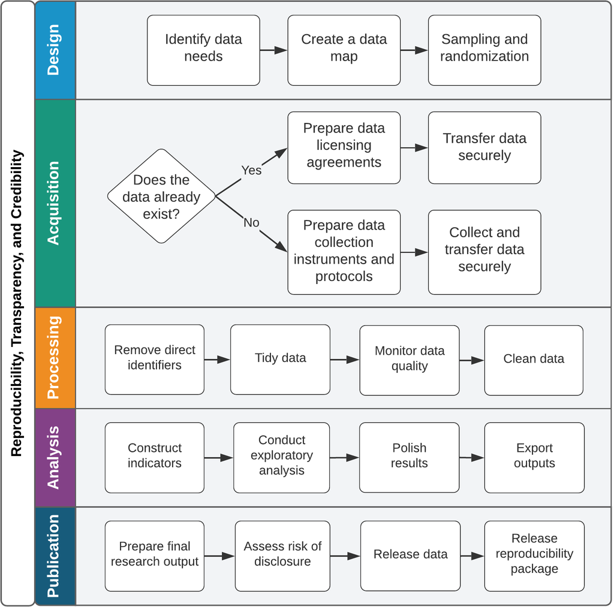

Overview of development research data work tasks

## Standardizing data work

In the past, data work was often treated as a “black box” in research. A published manuscript might exhaustively detail research designs, estimation strategies, and theoretical frameworks, but typically reserved very little space for detailed descriptions of how data was actually collected and handled. It is almost impossible to assess the quality of the data in such a paper, and whether the results could be reproduced. In the past decade, this has started to change,[^1] in part due to increasing requirements by publishers and funders to release code and data.

Data handling and documentation is a key skill for researchers and research staff. Standard processes and documentation practices are important throughout the research process to accurately convey and implement the intended research design,[^2] and to minimizes security risks: better protocols and processes lower the probability of data leakages, security breaches, and loss of personal information. When data work is done in an ad-hoc manner, it is very difficult for others to understand what is being done – a reader has to simply trust that the researchers did these things right. Most importantly, if any part of the data pipeline breaks down, research results become unreliable[^3] and cannot be faithfully interpreted as being an accurate picture of the intended research design.[^4] Because we almost never have “laboratory” settings[^5] in this type of research, such a failure has a very high cost: we will have wasted the investments that were made into knowledge generation, and the research opportunity itself, where we intended to conduct the study.[^6]

Accurate and reproducible data management and analysis is essential to the success and credibility of modern research. Standardizing and documenting data handling processes is essential to be able to evaluate and understand the data work alongside any final research outputs. An important component of this is **process standardization**.[^7] Process standardization means that there is little ambiguity about how something ought to be done, and therefore the tools to do it can be set in advance. Standard processes help other people understand your work, and they also make your work easier to document. Process standardization and documentation should allow readers of your code to: (1) quickly understand what a particular process or output is supposed to be doing; (2) evaluate whether or not it does that thing correctly; and (3) modify it either to test alternative hypotheses or to adapt into their own work. This book will discuss specific standards recommended by DIME Analytics, but we are more interested in convincing the reader to discuss the adoption of *a* standard within research teams than to necessarily use *the* particular standards that we recommend.

## Standardizing coding practices

Modern quantitative research relies heavily on standardized statistical software tools, written with various coding languages, to standardize analytical work. Outputs like regression tables and data visualizations are created using code in statistical software for two primary reasons. The first is that using a standard command or package ensures that the work is done right, and the second is that it ensures the same procedure can be confirmed or checked at a later date or using different data. Keeping a clear, human-readable record of these code and data structures is critical. While it is often *possible* to perform nearly all the relevant tasks through an interactive user interface or even through software such as Excel, this practice is strongly advised against. In the context of statistical analysis, the practice of writing all work using standard code is widely accepted. To support this practice, DIME now maintains portfolio-wide standards about how analytical code should be maintained and made accessible before, during, and after release or publication.

Over the last few years, DIME has extended the same principles to preparing data for analysis, which often comprises just as much (or more) of the manipulation done to the data over the life cycle of a research project. A major aim of this book is to encourage research teams to think of the tools and processes they use for designing, collecting, and handling data just as they do for analytical tasks. Correspondingly, a major contribution of DIME Analytics has been tools and standard practices for implementing these tasks using statistical software.

While we assume that you are going to do nearly all data work using code, many development researchers come from economics and statistics backgrounds and often understand code to be a means to an end rather than an output itself. We believe that this must change somewhat: in particular, we think that development practitioners must think about their code and programming workflows just as methodologically as they think about their research workflows, and think of code and data as research outputs, just as manuscripts and briefs are.

This approach arises because we see the code as the “recipe” for the analysis. The code tells others exactly what was done, how they can do it again in the future, and provides a roadmap and knowledge base for further original work.[^8] Performing every task through written code creates a record of every task you performed.[^9] It also prevents direct interaction with the data files that could lead to non-reproducible processes.[^10] Finally, DIME Analytics has invested a lot of time in developing code as a learning tool: the examples we have written and the commands we provide are designed to provide a framework for common practice across the entire DIME team, so that everyone is able to read, review, and provide feedback on the work of others starting from the same basic ideas about how various tasks are done.

Most specific code tools have a learning and adaptation process, meaning you will become most comfortable with each tool only by using it in real-world work. To support your process of learning reproducible tools and workflows, we reference free and open-source tools wherever possible, and point to more detailed instructions when relevant. **Stata**,[^11] as a proprietary software, is the notable exception here due to its persistent popularity in development economics and econometrics. This book also includes, in an appendix, the **DIME Analytics Coding Guide** which includes instructions for how to write good code, instructions on how to use the code examples in this book, as well as our Stata Style Guide. DIME projects are strongly encouraged to explicitly adopt and follow coding style guides in their work. Style guides harmonize code within and across teams making it easier to understand and reuse code, which ultimately helps teams to build on each other’s best practices. Some of the programming languages used at DIME already have well-established and commonly used style guides, such as the Tidyverse style guide for R and PEP-8 for Python.[^12]. Stata has relatively few resources of this type available, which is why we have created and included one here that we hope will be an asset to all Stata users.

## The team behind this book

DIME is the Development Impact Evaluation department of the World Bank.[^13] Its mission is to generate high-quality and operationally relevant data and research to transform development policy, help reduce extreme poverty, and secure shared prosperity.[^14] DIME develops customized data and evidence ecosystems to produce actionable information and recommend specific policy pathways to maximize impact. The department conduct research in 60 countries with 200 agencies, leveraging a US$180 million research budget to shape the design and implementation of US$18 billion in development finance. DIME also provides advisory services to 30 multilateral and bilateral development agencies.[^15] DIME research is organized into four primary topic pillars: Economic Transformation and Growth; Gender, Economic Opportunity, and Fragility; Governance and Institution Building; and Infrastructure and Climate Change. Over the years, DIME has employed dozens of research economists, and hundreds of full-time research assistants, field coordinators, and other staff. The team has conducted over 325 impact evaluations. *Development Research in Practice* exists to take advantage of that concentration and scale of research, to synthesize many resources for data collection and research, and to make DIME tools available to the larger community of development researchers.

As part of its broader mission, DIME invests in public goods to improve the quality and reproducibility of development research around the world. One key early innovation at DIME was the creation of [DIME Analytics](https://www.worldbank.org/en/research/dime/data-and-analytics), the team responsible for writing and maintaining this book. DIME Analytics is a centralized unit that develops and ensures adoption of high quality research practices across the department’s portfolio. This is done through an intensive, collaborative innovation cycle: DIME Analytics onboards and supports research assistants and field coordinators, provides standard tools and workflows to all teams, delivers hands-on support when new tasks or challenges arise, and then develops and integrates lessons from those engagements to bring to the full team. Resources developed and tested in DIME are converted into public goods for the global research community, through open-access trainings and open-source tools. The DIME Analytics Resource Directory appendix provides an introduction to public materials.

DIME Analytics has invested many hours over the past years learning from data work across DIME’s portfolio, identifying inefficiencies and barriers to success, developing tools and trainings, and standardizing best-practice workflows adopted in DIME projects. It has also invested significant energy in the language and materials used to teach these workflows to new team members, and, in many cases, in software tools that support these workflows explicitly. DIME team members often work on diverse portfolios of projects with a wide range of teammates, and we have found that standardizing core processes across all projects results in higher-quality work with fewer opportunities to make mistakes. In that way, the Analytics team is DIME’s method of institutionalizing tools and practices, developed and refined over time, that give the department a common base of knowledge and practice. In 2018, for example, DIME adopted universal reproducibility checks conducted by the Analytics team; the lessons from this practice helped move the DIME team from where 50% of submitted papers in 2018 required significant revision to pass to where 64% of papers passed in 2019 without revision required.

## Looking ahead

While adopting the workflows and mindsets described in this book requires an up-front cost, it will save you (and your collaborators) a lot of time and hassle very quickly. In part this is because you will learn how to implement essential practices directly; in part because you will find tools for the more advanced practices; and most importantly because you will acquire the mindset of doing research with a high-quality data focus.

For some readers, the amount of new tools and practices recommended in this book may seem daunting. We know from experience at DIME that full-scale adoption is possible; in the last few years, the full DIME portfolio has transitioned to transparent and reproducible workflows, with a fair share of hiccups along the way. The authors of this book supported that at-scale transition, and we hope that by sharing our lessons learned and resources, the learning curve for readers will be less steep. In the summary boxes at the beginning of each chapter, we provide a list of the key tools and resources to help readers prioritize. We will also offer “second-best” practices in many cases, suggesting easy-to-implement suggestions to increase transparency and reproducibility, in cases where full-scale adoption of the recommended workflows is not immediately feasible. In fact, we encourage teams to adopt one new practice at a time rather than rebuild their whole workflow from scratch right away. We hope that by the end of the book, all readers will have learned how to handle data more efficiently, effectively and ethically at all stages of the research process.

# 1 Conducting reproducible, transparent, and credible research

Policy decisions are made every day using the results of development research, and these have wide-reaching effects on the lives of millions. As the emphasis on evidence-based policy grows, so too does the scrutiny under which research methods and results are placed. Three major components make up this scrutiny: credibility, transparency, and reproducibility. These three components contribute to one simple idea: research should be high quality and well-documented. Research consumers, including the policy makers who will use the evidence to make decisions, should be able to easily examine and recreate such evidence. In this framework, it is useful to think of research as a public service that requires researchers as a group to be accountable for their methods. This means acting to collectively protect the credibility of development research by following modern practices for research planning and documentation. Across the social sciences, the open science movement has been fueled by concerns about the proliferation of low-quality research practices, data and code that are inaccessible to the public, analytical errors in major research papers, and in some cases even outright fraud. While the development research community has not yet experienced major scandals, it has become clear that there are necessary improvements to make in the way that code and data are handled as part of research. Moreover, having common standards and practices for creating and sharing materials, code, and data with others will improve the value of the work we do.

In this chapter, we outline principles and practices that help to ensure research consumers can be confident in the conclusions reached. We discuss each of the three components – credibility, transparency, and reproducibility – in turn. The first section covers research credibility. It presents three popular methods to commit to particular research questions or methods, and avoid potential criticisms of cherry-picking results: registration, pre-analysis plans, and registered reports. The second section discusses how to apply principles of transparency to all research processes, which allows research teams to be more efficient, and research consumers to fully understand and evaluate research quality. The final section provides guidance on how to make your research fully reproducible, and explains why publishing replication materials is an important research contribution in its own right.

### Summary: Conducting reproducible, transparent, and credible research

This chapter describes three pillars of a high-quality empirical research project: credibility, transparency and reproducibility. These steps and outputs discussed in this chapter should be prepared at the beginning of a project and revisited through the publication process.

**1. Credibility:** to enhance credibility, you should pre-commit research decisions as much as feasible

- Register research studies to provide a record of every project, so all evidence about a topic can be maintained; pre-register studies to protect design choices from later criticism.
- Write pre-analysis plans for data collection and analysis to both strengthen the conclusions drawn from those analyses and increase efficiency by creating a road map for project data work.
- Publish a registered report to combines the benefits of the two steps above with a formal peer review process and a conditional acceptance of the final results of the specified research.

**2. Transparency:** you should document all data acquisition and analysis decisions during the project lifecycle, with a clear understanding of what will be released publicly and plan for how those will be published

- Develop and publish comprehensive project documentation, especially instruments for data collection or acquisition that may be needed to prove ownership rights and facilitate re-use of the data.
- Retain all original data in an unaltered form and archive it appropriately, in preparation for it to be de-identified and published at the appropriate time.
- Write all data processing and analysis code with public release in mind.

**3. Reproducibility:** Prepare analytical work that can be verified and reproduced by others. This means

- Understanding what archives and repositories are appropriate for your various materials
- Preparing for legal documentation and licensing of data, code, and research products
- Initiating reproducible workflows that will easily transfer within and outside of your research team and the necessary documentation for others to understand and use your materials

#### Takeaways

**TTLs/PIs will:**

- Develop and document the research design and the corresponding data required to execute it
- Guide the research team in structuring and completing project registration
- Understand the team’s future rights and responsibilities regarding data, code, and research publication
- Determine what methods of pre-commitment are appropriate and lead the team in preparing them

**RAs will:**

- Rework outputs and documentation to meet specific technical requirements of registries, funders, publishers, or other governing bodies
- Inform the team leadership whenever methodologies, data strategies, or their planned executions are not sufficiently clear or are not appropriately documented or communicated
- Familiarize themselves with best practices for carrying out reproducible and transparent research, and initiate those practices within the research team

#### Key Resources

- Register your research study: https://dimewiki.worldbank.org/Study_Registration
- Create a pre-analysis plan: https://dimewiki.worldbank.org/Pre-Analysis_Plan
- Prepare to document research decisions: https://dimewiki.worldbank.org/Data_Documentation
- Publish data in a trusted repository: https://dimewiki.worldbank.org/Publishing_Data
- Prepare and publish a reproducibility package: https://dimewiki.worldbank.org/Reproducible_Research

## Developing a credible research project

The evidentiary value of research is traditionally a function of design choices,[^16] such as powered through sampling and randomization, and robustness to alternative specifications and definitions. One frequent target for critics of such research[^17] is the fact that most researchers have a lot of leeway in selecting their projects, results, or outcomes *after* already having had the experience of implementing a project or collecting data in the field, which increases the likelihood of finding “false positive” results that are not true outside carefully-selected data.[^18] Credible research design methods are key to maintaining credibility in these choices and avoiding serious errors. This is especially relevant for research that relies on original data sources, from innovative big data sources to unique surveys. Development researchers should take these concerns seriously. Such flexibility can be a significant issue for the quality of evidence overall, particularly if researchers believe that certain types of results are substantially better for their careers or their publication chances.

This section presents three popular methods for researchers to commit to particular research questions or methods, and to avoid potential criticisms of cherry-picking results for publication: registration, pre-analysis plans, and registered reports. Each of these methods involves documenting specific research design components, ideally before carrying out the analytical component or extensively exploring the data. Study registration provides formal notice that a study is being attempted and creates a hub for materials and updates about the study results. Pre-analysis plans are a more formal commitment to use specific methods on particular questions. Writing and releasing a pre-analysis plan in advance of working with data is used to protect the credibility of approaches that have a high likelihood of producing false results.[^19] Finally, registered reports allow researchers to approach research planning itself as a process at the level of a full peer review. Registered reports enable close scrutiny of a research design, a feedback and improvement process, and a commitment from a publisher to publish the study based on the credibility of the design, rather than the specific results.

### Registering research studies

Registration of research studies is an increasingly common practice, and more journals are beginning to require the registration of studies they publish.[^20] Study registration intended to ensure that a complete record of research inquiry is easily available.[^21] Registering research studies ensures that future scholars can quickly find out what work has been carried out on a given question, even if some or all of the work done never results in formal publication. Registration of studies is increasingly required by publishers and can be done before, during, or after the study with essential information about the study purpose. Some currently popular registries are operated by the [**AEA**](https://www.socialscienceregistry.org), [**3ie**](https://ridie.3ieimpact.org), [**eGAP**](https://egap.org/content/registration), and [**OSF**](https://osf.io/registries). They all have different target audiences and features, so select one that is appropriate to your work. Study registration should be feasible for all projects, as registries are typically free to access and can be initially submitted with minimal information about the project. A generally-acceptable practice will be to gradually revise and expand the level of detail in a registration over time, adding more information as the planning for the project progresses.

Pre-registering studies before they begin is an extension of this principle.[^22] Registration of a study before it goes to implementation or data acquisition, particularly when specific hypotheses are included in the registration, provides a simple and low-effort way for researchers to conclusively demonstrate that a particular line of inquiry was not generated by the process of data collection or analysis itself.[^23] Pre-registrations need not provide exhaustive details about how a particular hypothesis will be approached; only that it will be. Pre-registering specific individual elements of research design or analysis can be highly valuable for the credibility of the research and requires only minor time investment or administrative effort. For this reason, the DIME team requires pre-registration of all studies in a public database with at least some primary hypotheses prespecified, prior to providing funding for impact evaluation research.

### Demand for Safe Spaces Case Study: Registering Research Studies

The experimental component of the *Demand for Safe Spaces* study was registered at the Registry for International Development Impact Evaluations (RIDIE) under ID 5a125fecae423.

Highlights from the Registry:

- *Indicated evaluation method:* both primary method (randomized control trial) and additional methods (difference-in-difference/fixed effects).
- *Listed key outcome variables:* take-up of rides in women-only car (binary), occurrence of harassment or crime during ride (binary), self-reported well-being after each ride, overall subjective well-being, Implicit Association Test D-Score
- *Specified primary hypotheses to be tested:* The women-only car reduces harassment experienced by women who ride it; Riding the women’s-only car improves psychological well-being of those who ride it; Women are willing to forego income to ride the women’s-only car
- *Specified secondary research question and methods:* supplementary research methods (implicit association test and platform survey) to help address an additional hypothesis: The women’s-only car is associated with a social norm that assigns responsibility to women for avoiding harassment.
- *Provided sample size for each study arm:* number of individual participants, number of baseline rides, number of rides during price experiment, number of car-assigned rides, number of expected participants in implicit association test
- *Described data sources: the study relied on data previously collected (through the mobile app) and data to-be-collected (through platform surveys and implicit association tests)
- *Registration status:* categorized as a non-prospective registry, as the crowdsourced data had already been received and processed. It was important to the team to ensure the credibility of additional data collection and secondary research questions by registering the study.

> The RIDIE registry can be accessed at https://ridie.3ieimpact.org/index.php?r=search/detailView&id=588

### Writing pre-analysis plans

If a research team has a large amount of flexibility to define how they approach a particular hypothesis, study registration may not be sufficient to avoid the criticism of “hypothesizing after the results are known”, or HARKing.[^24] Examples of such flexibility include a broad range of concrete measures that could be argued to measure to an abstract concept; future choices about sample inclusion or exclusion; or decisions about how to construct derived indicators. There are a variety of templates and checklists of details to include.[^25] When the researcher is collecting a large amount of information and has leverage over even a moderate number of these options, it is almost guaranteed that they can come up with any result they like.[^26]

Pre-analysis plans (PAPs) can be used to assuage these concerns by specifying some set of analyses the researchers intend to conduct.[^27] The pre-analysis plan should be written up in detail for areas that are known to provide a large amount of leeway for researchers to make later decisions, particularly for things like interaction effects or subgroup analysis.[^28] Pre-analysis plans shoud not, however, be viewed as binding the researcher’s hands.[^29] Depending on what is known about the study at the time of writing, pre-analysis plans can vary widely in the amount of detail they should include.[^30] The core function of a PAP is to carefully and explicitly describe one or more specific data-driven inquiries, as specific formulations are often very hard to justify in retrospect with data or projects that potentially provide many avenues to approach a single theoretical question.[^31] Anything outside the original plan is just as interesting and valuable as it would have been if the plan was never published; but having pre-committed to the details of a particular inquiry makes its results immune to a wide range of criticisms of specification searching or multiple testing.[^32]

### Demand for Safe Spaces Case Study: Writing Pre-Analysis Plans

Although the *Demand for Safe Spaces* study did not publish a formal pre-analysis plan, the team published a concept note in 2015, which includes much of the same information as a typical pre-analysis plan. The Concept Note was updated in May 2017 to include new secondary research questions. The Concept Note, prepared before fieldwork began, was subject to review and approval within the World Bank and from a technical committee including blinded feedback from external academics. The Concept Note specified the planned study along the following dimensions:

- *Theory of change:* the main elements of the intervention, and the hypothesized causal chain from inputs, through activities and outputs, to outcomes.
- *Hypotheses* derived from the theory of change
- *Main evaluation question(s)* to be addressed by the study
- *List of main outcomes of interest,* including outcome name, definition, level of measurement
- *Evaluation design,* including a precise description of the identification strategy for each research questions and description of treatment and control groups
- *Sampling strategy and sample size calculation,* detailing the assumptions made
- *Description of all quantitative data collection instruments*
- *Data processing and analysis:* the statistical methods to be used, the exact specification(s) to be run, including clustering of standard errors; key groups for heterogeneity analysis; adjustments for multiple hypothesis testing; strategy to test (and correct) for bias.

> A version of the study’s Concept Note is available at https://github.com/worldbank/rio-safe-space/blob/master/Online%20Appendices/Supplemental%20Material/Project%20Concept%20Note.pdf

### Publishing registered reports

**Registered reports** take the process of pre-specifying a complex research design to the level of a formal publication.[^33] In a registered report, a journal or other publisher will peer review and conditionally accept a specific study for publication, typically then guaranteeing the acceptance of a later publication that carries out the analysis described in the registered report. While far stricter and more complex to carry out than ordinary study registration or pre-analysis planning, the registered report has the added benefit of peer review and expert feedback on the design and structure of the proposed study.[^34] Registered reports are never required, but they are designed to reward researchers who are able to provide a large amount of advance detail for their projects, researchers who want to secure publication interest regardless of results, or researchers who want to use methods that may be novel or unusual.

This process is in part meant to combat the “file-drawer problem”[^35] and ensure that researchers are transparent in the sense that all promised results obtained from registered-report studies are actually published. This approach has the advantage of pre-specifying in great detail a complete research and analytical design, and securing a commitment for publication regardless of the outcome. This may be of special interest for researchers studying events or programs where either there is a substantial risk that they would either not be able to publish a null or negative result,[^36] or where they may wish to avoid any pressure toward finding a particular result, for example when the program or event is the subject of substantial social or political pressures. As with pre-registration and pre-analysis, nothing in a registered report should be understood to prevent a researcher from pursuing additional avenues of inquiry once the study is complete, either in the same or separate research outputs.

## Conducting research transparently

Transparent research exposes not only the code, but all research processes involved in developing the analytical approach. This means that readers are able to judge for themselves whether the research was done well and the decision-making process was sound. If the research is well-structured, and all of the relevant documentation[^37] is shared, it is easy for the reader to understand the analysis fully. Researchers that expect process transparency also have an incentive to make better decisions, be skeptical and thorough about their assumptions, and save themselves time, because transparent research methods are labor-saving over the complete course of a project.

Clearly documenting research work is necessary to allow others to evaluate exactly what data was acquired and how it was used to obtain a particular result. Many development research projects are purpose-built to address specific questions, and often use unique data, novel methods, or small samples. These approaches can yield new insights into essential academic questions, but need to be transparently documented so they can be reviewed or replicated by others in the future.[^38] Unlike disciplines where data is more standardized or where research is more oriented around secondary data, the exact data used in a development project has often not been observed by anyone else in the past and may not be able to be re-collected by others in the future. Regardless of the novelty of study data, transparent documentation methods help ensure that data was collected and handled appropriately and that studies and interventions were implemented correctly. As with study registrations, project and data documentation should be released on external **archival repositories**[^39] so they can always be accessed and verified.

### Documenting data acquisition and analysis

Documenting a project in detail greatly increases transparency. Many disciplines have a tradition of keeping a “lab notebook”, and adapting and expanding this process to create a lab-style workflow in the development field is a critical step towards more transparent practices. This means explicitly noting decisions as they are made, and explaining the process behind the decision-making. Careful documentation will also save the research team a lot of time during a project, as it prevents you from having the same discussion twice (or more!), since you have a record of why something was done in a particular way. There are a number of available tools that will contribute to producing documentation, but project documentation should always be an active and ongoing process, not a one-time requirement or retrospective task. New decisions are always being made as the plan begins contact with reality, and there is nothing wrong with sensible adaptation so long as it is recorded and disclosed.

Email, however, is *not* a documentation service, because communications are rarely well-ordered, can be easily deleted, and are not available for future team members. At the very least, emails and other decision-making communications need to be archived and preserved (as, say, PDFs) in an organized manner so that they can be easily accessed and read by others in the future. There are also various software solutions for building proper documentation over time. Some work better for field records such as implementation decisions, research design, and survey development; others work better for recording data work and code development. The **Open Science Framework**[^40] provides one such solution, with integrated file storage, version histories, and collaborative wiki pages. **GitHub**[^41] provides a transparent documentation system through commit messages, issues, `README` files, and pull requests,[^42] in addition to version histories and wiki pages. Such services offer multiple different ways to record the decision process leading to changes and additions, track and register discussions, and manage tasks. These are flexible tools that can be adapted to different team and project dynamics. Services that log your research process can show things like modifications made in response to referee comments, by having tagged version histories at each major revision. They also allow you to use issue trackers to document the research paths and questions you may have tried to answer as a resource to others who have similar questions. Each project has specific requirements for data, code, and documentation management, and the exact transparency tools to use will depend on the team’s needs, but they should be agreed upon prior to project launch. This way, you can start building a project’s documentation as soon as you start making decisions.

### Cataloging and archiving data

Data and data collection methods should be fully cataloged, archived, and documented, whether you are collecting data yourself or receiving it from an outside partner. In some cases this is as simple as uploading a survey instrument or an index of datasets and a codebook to an archive. In other cases this will be more complex. Proper documentation of data collection will often require a detailed description of the overall sampling procedure.[^43] For example, settings with many overlapping strata, treatment arms, excluded observations, or resampling protocols might require extensive additional field work documentation. This documentation should be continuously updated and kept with the other study materials; it is often necessary to collate these materials for an appendix for publication in any case.

When data is received from partners or collected in the field, the **original data** (including corrections)[^44] should be immediately placed in a secure permanent storage system. Before analytical work begins, you should create a “for-publication” copy of the original dataset by removing potentially identifying information. This will become the raw data, and must be placed in an archival repository where it can be cited.[^45] This can initially be done under embargo or with limited release, in order to protect your data and future work. This type of data depositing or archiving precedes publishing or releasing any data: data at this stage may still need to be embargoed or have other, potentially permanent, access restrictions, so you can instruct the archive to formally release the data later. If your planned analysis requires the use of unpublishable data, that data should always remain encrypted and be stored separately so it is clear what portions of the code will work with and without obtaining a license to the needed restricted-access data.

## Analyzing data reproducibly

Reproducible research makes it easy for others to apply your techniques to new data or to implement a similar research design in a different context. Development research is rapidly moving in the direction of requiring adherence to specific reproducibility guidelines.[^51] Major publishers and funders, most notably the American Economic Association, have taken steps to require that code and data are accurately reported, cited, and preserved as research outputs that can be accessed and verified by others. Making research reproducible in this way is a public good.[^52] It enables other researchers to re-use code and processes to do their own work more easily and effectively in the future. Regardless of what is formally required, your code should be written neatly with clear instructions. It should be easy to read and understand. The corresponding analysis data should also be made accessible to the greatest legal and ethical extent that it can be.[^53]

Common research standards from journals and funders feature both regulation and verification policies.[^54] Regulation policies require that authors provide reproducibility packages before publication which are then reviewed by the journal for completeness.[^55] Verification policies require that authors make certain materials available to the public, but their completeness is not a precondition for publication. Other journals have adopted guidance that offer checklists for reporting on whether and how various practices were implemented, without specifically requiring any.[^56] If you are personally or professionally motivated by citations, producing these kinds of resources can lead to that as well. Even if privacy considerations mean you will not be publishing some or all data or results, these practices are still valuable for project organization.

Our recommendation, regardless of external requirements, is that your should prepare to release all data that can be published When data cannot be published, you should try to publish as much metadata as allowed, including information on how the data was obtained, what fields the data contains and aggregations or descriptive statistics. Even if the data cannot be published, it is rare for code files to contain restricted information, so the code should still be made available with clear instructions for obtaining usable data. Additionally, we recommend that reproducibility efforts be considered when designing the IRB and data licensing agreement for sensitive data, to establish acceptable conditions (such as a secure transfer or cold room) under which representatives from journals or other academics could access data may access the data for the purpose of independently reproducing results.

### Preparing a reproducibility package

At DIME, all research outputs are required to satisfy **computational reproducibility**,[^57] which is an increasingly common requirement for publication.[^58] Before releasing a working paper, the research team submits a **reproducibility package** with de-identified data, and DIME Analytics verifies that the package produces exactly the same results that appear in the paper.[^59] The team also comments on whether the package includes sufficient documentation. The Analytics team organizes frequent peer code review for works in progress, and our general recommendation is to ensure that projects are *always* externally reproducible instead of waiting until the final stages to prepare this material. Once the computational reproducibility check is complete, the team receives a completed reproducibility certificate that also lists any publicly available materials to accompany the package, for use as an appendix to the publication. The team also organizes regular peer code review for works in progress, and our general recommendation is to ensure that projects are *always* externally reproducible instead of waiting until the final stages to prepare this material. In this way, code is continuously maintained with clear documentation, and should be easy to read and understand in terms of structure, style, and syntax.

For research to be reproducible, all code files for data cleaning, construction and analysis should be public, unless they contain confidential information. Nobody should have to guess what exactly comprises a given index, or what controls are included in your main regression, or whether or not you clustered standard errors correctly. That is, as a purely technical matter, nobody should have to “just trust you”, nor should they have to bother you to find out what would happen if any or all of these things were to be done slightly differently.[^60] Letting people play around with your data and code is a great way to have new questions asked and answered based on the valuable work you have already done.[^61]

A reproducibility package should include the complete materials needed to exactly re-create your final analysis, and be accessible and well-documented so that others can identify and adjust potential decision points that they are interested in. They should be able to easily identify: what data was used and how that data can be accessed; what code generates each table, figure and in-text number; how key outcomes are constructed; and how all project results can be reproduced. This is important to plan ahead for, so that you can make sure you obtain the proper documentations and permissions for all data, code, and materials you use throughout the project. A well-organized reproducibility package usually takes the form of a complete directory structure, including documentation and a master script, that leads the reader through the process and rationale for the code behind each of the outputs when considered in combination with the corresponding publication.

### Demand for Safe Spaces Case Study: Preparing a Reproducibility Package

The *Demand for Safe Spaces* team published all final study materials to a repository on the World Bank’s GitHub account. The repository holds the abstract of the paper, ungated access to the most recent version of the full paper, an online appendix including robustness checks and supplemental material, and the project’s reproducibility package.

The data for this project is published in the Microdata Catalog, under the survey ID number BRA_2015-2016_DSS_v01_M. The Microdata catalog entry includes metadata on the study, documentation such as survey instruments and technical reports, terms of use for the data, and access to downloadable data files. Both the crowdsourced data and the platform survey data are accessible through the Microdata Catalog.

The “Reproducibility Package” folder on GitHub contains all the instructions for executing the code. Among other things, it provides licensing information for the materials, software and hardware requirements including time needed to run, and instructions for replicators (which are included below). Finally, it has a detailed list of the code files that will run, their data inputs, and the outputs of each process.

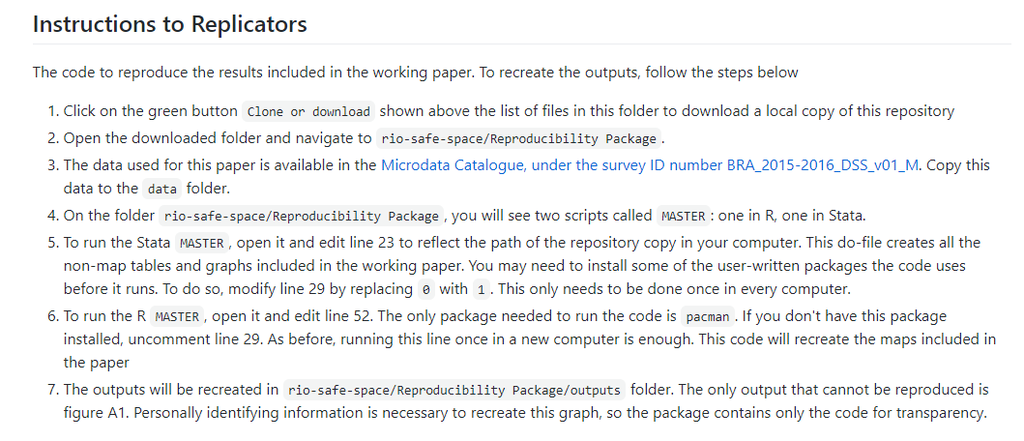

> The Demand for Safe Space GitHub repository can be viewed at : https://github.com/worldbank/rio-safe-space

> The Microdata Catalog entry for the study is available at https://microdata.worldbank.org/index.php/catalog/3745

## Looking ahead

With the ongoing rise of empirical research and increased public scrutiny of scientific evidence, making analysis code and data available is necessary but not sufficient to guarantee that findings will be credible. Even if your methods are highly precise, your evidence is only as good as your data – and there are plenty of mistakes that can be made between establishing a design and generating final results that would compromise its conclusions. That is why transparency is key for research credibility. It allows other researchers, and research consumers, to verify the steps to a conclusion by themselves, and decide whether their standards for accepting a finding as evidence are met. Every investment you make in documentation and transparency up front protects your project down the line, particularly as these standards continue to tighten. With these principles in mind, the approach we take to the development, structure, and documentation of data work provides a system to implementing these ideas in everyday work. In the next chapter, we will discuss the workspace you need in order to work reproducibly in an efficient, organized, and secure manner.

# 2 Setting the stage for effective and efficient collaboration

In order to do effective data work in a team environment, you need to structure your workflow in advance. Preparation for collaborative data work begins long before you acquire any data, and involves planning both software tools and collaboration platforms for your team. This means knowing what types of data you’ll acquire, whether the data will require special handling due to size or privacy considerations, which datasets and outputs you will need at the end of the process, and how all data files and versions will stay organized throughout. It’s important to plan data workflows in advance because changing software or protocols halfway through a project is costly and time-consuming. Seemingly small decisions such as file-sharing services, folder structures, and filenames can be extremely painful to alter down the line in any project.

This chapter will guide you in setting up an effective environment for collaborative data work, structuring your data work to be well-organized and clearly documented, and setting up processes to handle confidential data securely. The first section outlines how to set up your working environment to effectively collaborate on technical tasks with others, and how to document tasks and decisions. The second section discusses how to organize your code and data so that others will be able to understand and interact with it easily. The third section provides guidelines for ensuring privacy and security when working with confidential data.

### Summary: Setting the stage for effective and efficient collaboration Summary

The technical environment for your data work needs to be established at the start of a research project. Agreeing with the team on software choices, standard code and data structure, and clear data security protocols will prepare you to successfully, safely, and efficiently implement technical tasks throughout the project lifecycle. Consider:

**1. Technical collaboration environment.** No matter the hardware and software your team plans to use, you should ensure now that it is standardized or interoperable across the team. This includes:

- Secure all **physical computing hardware** through encryption and password-protection. If specialized or more powerful hardware is required, initiate access requests, purchase orders, or other processes now
- Agree on tools for **collaboration** and documentation, such that key conversations and decisions are archived and organized outside of instant-message and email conversation
- Decide the **programming languages and environments** the team will use. Take time to set up a comfortable and modern digital work environment

**3. Information security measures and ethical frameworks**. These include:

- Formally **request and obtain approval** from legal entities governing research in all relevant jurisdictions
- Understand **how to respect the rights and dignity of research subjects** and plan for how to establish **informed consent** from individuals or groups participating in the research
- Adopt standardized **digital security practices** including proper encryption of all confidential information, at rest and in transit, both among your team and with external partners

#### Takeaways

**TTLs/PIs will:**

- Support the acquisition and maintenance of required computing hardware and software, liaising with procurement, information security and information technology teams as necessary
- Make final decisions regarding code languages and environments
- Discuss and agree upon an appropriate project-wide digital organization strategy
- Institute and communicate best practices in accordance with legal, ethical, and security obligations

**RAs will:**

- Communicate technical needs clearly with TTLs/PIs and relevant service providers
- Consistently implement digital organization strategy and flag issues with task management, documentation, or materials storage if they arise
- Support project compliance with ethical, legal, and security obligations and flag concerns to TTLs/PIs

#### Key Resources

- DIME Research Ethics Standards: Pillar 1 of the DIME Research Standards https://github.com/worldbank/dime-standards
- DIME GitHub Resources: https://github.com/worldbank/dime-github-trainings
- DIME Data Security Standards: Pillar 4 of the DIME Research Standards https://github.com/worldbank/dime-standards
- DIME Data Publication Standards: Pillar 5 of the DIME Research Standards https://github.com/worldbank/dime-standards

## Preparing a collaborative work environment

This section introduces core concepts and tools for organizing data work in an efficient, collaborative and reproducible manner. Some of these skills may seem elementary, but thinking about simple things from a workflow perspective can help you make marginal improvements every day you work; those add up to substantial gains over the course of multiple years and projects. Together, these processes form a collaborative workflow that will greatly accelerate your team’s ability to get tasks done on all your projects.

Teams often develop workflows in an ad hoc fashion, solving new challenges as they arise. Adaptation is good, of course. But it is important to recognize that there are a number of tasks that exist in common for every project, and it is more efficient to agree on the corresponding workflows in advance. For example, every project requires research documentation, organized file naming, directory organization, coding standards, version control, and code review. These tasks are common to almost every project, and their solutions translate well between projects. Therefore, there are large efficiency gains to thinking in advance about the best way to do these tasks, instead of throwing together a solution when the task arises. This section outlines the main points to discuss within the team, and suggests best practice solutions for these tasks.

### Demand for Safe Spaces Case Study: Preparing a Collaborative Work Environment

Here are a few highlights of how the **Demand for Safe Spaces** team chose to organize their work environment for effective collaboration:

- The data work for the project was done through a private GitHub repository housed in the World Bank organization account.
- GitHub issues were used to document research decisions and to provide feedback. Even the PIs for the study, who did not directly participate in coding, used Github issues to review code and outputs and to create a record of broader discussions.
- Stata was adopted as the primary software for data analysis, as that is the software all team members had in common at the start of the project. At a later stage of the project, R code was developed specifically to create maps. The R portion of the code was developed independently, as it used different datasets and created separate outputs. The team used two separate master scripts, one for the Stata code base and one for the R code.
- The team members shared a synchronized folder (using Dropbox), which included the de-identified data and project documentation such as survey instruments and enumerator training manuals.

### Setting up your computer

First things first: almost all your data work will be done on your computer, so make sure it’s set up for success. The operating system should be fully updated, it should be in good working order, and you should have a **password-protected** login. However, password-protection is not sufficient if your computer stores data that is not public. You would need to use encryption for sufficient protection, which will be covered later in this chapter. Make sure your computer is backed up to prevent information loss. Follow the **3-2-1 rule**: maintain 3 copies of all original or irreplaceable data, on at least 2 different hardware devices you have access to, with 1 offsite storage method.[^62] Chapter 4 provides a protocol for implementing this.

Ensure you know how to get the **absolute file path** for any given file. On MacOS this will be something like “`/users/username/git/project/...`” and “`C:/users/username/git/project/...`” on Windows. Absolute file paths will be an obstacle to collaboration unless they are **dynamic absolute file paths**. In a dynamic absolute file path the relative project path, “`/git/project/...`” in the examples above, is added to the user-specific root path for each user, “`/users/username`” or “`C:/users/username`” in the examples above, generating an absolute file path unique to each user. Master scripts introduced later in this chapter will show how this can be seamlessly implemented. Dynamic absolute file paths, starting from the file system root, is the best way to ensure that files are read and written correctly when multiple users work on the same project across many different platforms, operative systems and devices. There are contexts, for example some cloud environments, where relative file paths must be used, but in all other contexts we recommend you to always use dynamic absolute file paths.

Use forward slashes (`/`) in file paths for folders, and whenever possible use only the 26 English characters, numbers, dashes (`-`), and underscores (`_`) in folder names and filenames.[^63] For emphasis: *always* use forward slashes (`/`) in file paths in code, just like in internet addresses. Do this even if you are using a Windows machine where both forward and backward slashes are allowed, as your code will otherwise break if anyone tries to run it on a Mac or Linux machine. Making the structure of your directories a core part of your workflow is very important, since otherwise you will not be able to reliably transfer the instructions for replicating or carrying out your analytical work.

When you are working with others, you will most likely be using some kind of **file sharing** software. The exact services you use will depend on your tasks, but in general, there are several approaches to file sharing, and the three discussed here are the most common. **File syncing** is the most familiar method, and is implemented by software like OneDrive, Dropbox, or Box. Sync forces everyone to have the same version of every file at the same time, which makes simultaneous editing difficult but other tasks easier. **Distributed version control** is another method, commonly implemented through systems like GitHub, GitLab, and Bitbucket that interact with Git.[^64] Distributed version control allows everyone to access different versions of files at the same time. It is only optimized for specific types of files (for example, any type of code files). Finally, **server storage** is the least-common method, because there is only one version of the materials, and simultaneous access must be carefully regulated. Server storage ensures that everyone has access to exactly the same files and environment, and it also enables high-powered computing processes for large and complex data.

All three file sharing methods are used for collaborative workflows, and you should review the types of data work that you will be doing, and plan which types of files will live in which types of sharing services. It is important to note that they are, in general, not interoperable, meaning you should not have version-controlled files inside a syncing service, or vice versa, without setting up complex workarounds, and you cannot shift files between them without losing historical information. Therefore, choosing the correct sharing service for each of your team’s needs at the outset is essential. At DIME we typically use file syncing for all project administrative files and data, version control in Git for code, and server storage for backup and/or large scale computations when needed.

### Establishing effective documentation practices

Once your technical and sharing workspace is set up, you need to decide how you are going to communicate with your team. The first habit that many teams need to break is using instant communication for management and documentation. Email is, simply put, not a system. It is not a system for anything. Neither is instant messaging apps like WhatsApp. Instant messaging tools are developed for communicating “now” and that is what they do well. They are not structured to manage group membership or to present the same information across a group of people, or to remind you when old information becomes relevant. They are not structured to allow people to collaborate over a long time or to review old discussions. It is therefore easy to miss or lose communications from the past when they have relevance in the present. Everything with future relevance that is communicated over email or any other instant medium – such as, for example, decisions about research design – should immediately be recorded in a system that is designed to keep permanent records. We call these systems collaboration tools, and there are several that are very useful.

Good collaboration tools are workflow-oriented systems that allow the team to create and assign tasks, carry out discussions related to single tasks, track task progress across time, and quickly see the overall project status. They are web-based so that everyone on your team can access them simultaneously and have ongoing discussions about tasks and processes. Such systems link communications to specific tasks so that related decisions are permanently recorded and easy to find in the future when questions about that task come up. Choosing the right tool for your team’s needs is essential to designing an effective workflow. What is important is that your team chooses a system and commits to using it, so that decisions, discussions, and tasks are easily reviewable long after they are completed.

Some popular and free collaboration tools that meet these criteria are GitHub and Dropbox Paper. Any specific list of software will quickly be outdated; we mention these as examples that have worked for our team. Different collaboration tools can be used different types of tasks. Our team, for example, uses GitHub for code-related tasks, and Dropbox Paper for more managerial tasks. GitHub creates incentives for writing down why changes were made in response to specific discussions as they are completed, creating naturally documented code. It is useful also because tasks in GitHub Issues can clearly be tied to file versions. On the other hand, Dropbox Paper provides a clean interface with task notifications, assignments, and deadlines, and is very intuitive for people with non-technical backgrounds. Therefore, it is a useful tool for managing non-code-related tasks.

### Setting up your code environment

Taking time early in your project to choose a programming language to work in and setting up a productive code environment for that language will make your work significantly easier. Setting up a productive code environment means to make sure that the programming language and all other software your code requires will run smoothly on all the hardware you need it to run on. It also means that you have a productive way of interacting with code, and that the code has a seamless method to access your data.

It is difficult and costly to switch programming languages halfway through a project, so think ahead about the various software your team will use. Take into account the technical abilities of team members, what type of internet access the software will need, the type of data you will need to access, and the level of security required. Big datasets require additional infrastructure and may overburden the tools commonly used for small datasets. Also consider the cost of licenses, the time to learn new tools, and the stability of the tools. There are few strictly right or wrong choices for software, but what is important is that you plan in advance and understand how the chosen tools will interact with your workflows.

One option is to hold your code environment constant over the lifecycle of a single project. While this means you will inevitably have different projects with different code environments, each successive project will be better than the last, and you will avoid the costly process of migrating an ongoing project into a new code environment. Code environments should be documented as precisely as possible. The specific version number of the programming languages and the individual packages you use should be referenced or maintained so that they can be reproduced going forward, even if different releases contain changes that would break your code or change your results. DIME Analytics developed the command `ieboilstart` in the `ietoolkit` package to support version and settings stability in Stata.[^65] If your project requires more than one programming language, for example if you analyze your data in one language but visualize your results in another, then make sure to make an as clear division between the two as possible. This means that you first complete all tasks done in one language, before the completing the rest of the tasks in the other language. Frequently swapping back and forth between languages is a reproducibility nightmare.

Next, think about how and where you write and execute code. This book is intended to be agnostic to the size or origin of your data, but we are going to broadly assume that you are using one of the two most popular statistical software packages: R or Stata. (If you are using another language, like Python, many of the same principles apply but the specifics will be different.) Most of your code work will be done in a code editor. If you are working in R, **RStudio** is the typical choice.[^66] For Stata, the built-in do-file editor is the most widely adopted code editor. You might also consider using an external editor for your R or Stata code.[^67] These editors offer great accessibility and quality features. For example, they can access an entire directory – rather than a single file – which gives you directory-level views and file management actions, such as folder management, Git integration, and simultaneous work with other types of files, without leaving the editor. Using an external editor can also be preferable since your editor will not crash if the execution of your code causes your statistical software to crash. Finally, you can often use the same editor for all programming languages you use, so any customization you do in your code editor of choice will improve your productivity across all your coding work.

## Organizing code and data for replicable research

We assume you are going to do your analytical work through code, and that you want all your processes to be documented and replicable. Though it is possible to interact with some statistical software through the user interface without writing any code, we strongly advise against it. Writing code creates a record of every task you performed. It also prevents direct interaction with the data files that could lead to non-reproducible steps. You may do some exploratory tasks by point-and-click or typing directly into the console, but anything that is included in a research output must be coded in an organized fashion so that you can release the exact code that produces your final results – up to and including individual statistics in text. Still, organizing code and data into files and folders is not a trivial task. What is intuitive to one person rarely comes naturally to another, and searching for files and folders is everybody’s least favorite task. As often as not, you come up with the wrong one, and then it becomes very easy to create problems that require complex resolutions later. This section provides basic tips on managing the folder that stores your project’s data work.

Maintaining an organized file structure for data work is the best way to ensure that you, your teammates, and others are able to easily edit and replicate your work in the future. It also ensures that automated processes from code and scripting tools are able to interact well with your work, whether they are yours or those of others. File organization makes data work easier as well as more transparent, and facilitates integration with tools like version control systems that aim to cut down on the amount of repeated tasks you have to perform. It is worth thinking in advance about how to store, name, and organize the different types of files you will be working with, so that there is no confusion down the line and everyone has the same expectations.

### Organizing files and folders

Once you start a research project, the number of scripts, datasets, and outputs that you have to manage will grow very quickly. This can get out of hand just as quickly, so it’s important to organize your data work and follow best practices from the beginning. You should agree with your team on a specific directory structure, and set it up at the beginning of the project. You should also agree on a file naming convention. This will help you to easily find project files and ensure that all team members can easily run the same code.

To support consistent folder organization at DIME, DIME Analytics created `iefolder` as a part of our `ietoolkit` package.[^68] This Stata command sets up a pre-standardized folder structure for what we call the `DataWork` folder.[^69] The `DataWork` folder includes folders for all the steps of a typical project. Since each project will always have unique needs, we have tried to make the structure easy to adapt. Having a universally standardized folder structure across the entire portfolio of projects means that everyone can easily move between projects without having to reorient on file and folder organization.

If you do not already have a standard file structure across projects, `iefolder` is an easy template to start from. The command creates a `DataWork` folder at the project level, and within that folder, creates standardized directory structures for each data source or survey round. Within each subdirectory, `iefolder` creates folders for raw encrypted data, raw deidentified data, cleaned data, final data, outputs, and documentation. It creates a parallel folder structure for the code files that move the data through this progression, and for the final analytical outputs. The `ietoolkit` package also includes the `iegitaddmd` command, which can place `README.md` placeholder files in your folders so that your folder structure can be shared using Git.[^70] Since these placeholder files are written in a plaintext language called **Markdown**, they also provide an easy way to document the contents of every folder in the structure.

The `DataWork` folder may be created either inside an existing project folder, or it may be created as a separate root folder. We advise keeping project management materials (such as contracts, terms of reference, briefs and other administrative or management work) separate from the `DataWork` folder structure. It is useful to maintain project management materials in a sync system like Dropbox, whereas the code folder should be maintained in a version-control system like Git. However, a version-controlled folder should *never* be stored in a synced folder that is shared with other people. Combining these two types of collaboration tools almost always creates undesired functionalities.

### Demand for Safe Spaces Case Study: Organizing Files and Folders

The diagram below illustrates the folder structure for the *Demand for Safe Spaces* data work. Note that this project started before the `iefolder` structured was created, and so differs from the current guidelines. Changing folder organization midway through a project is never recommended. The key feature of folder organization is planning ahead and agreeing with the whole team on the best structure to follow.

The root folder for the study’s data work included two master scripts (one for Stata and one R, that can be run independently), a readme, and 4 subfolders: data, code, documentation and outputs. The folder structure was identical in GitHub and DropBox, but the files present in each of them differed. All code, raw outputs (such as TeX table fragments and PNG images) and plain text documentation were stored in GitHub. All the datasets, PDF outputs and documentation in Word and Excel were stored in DropBox. When data processing was completed, binary files in the Documentation folder that were accessed by the code, such as `iecodebook` and `ieduplicates` spreadsheets, were moved to GitHub to ensure completeness of the repository.

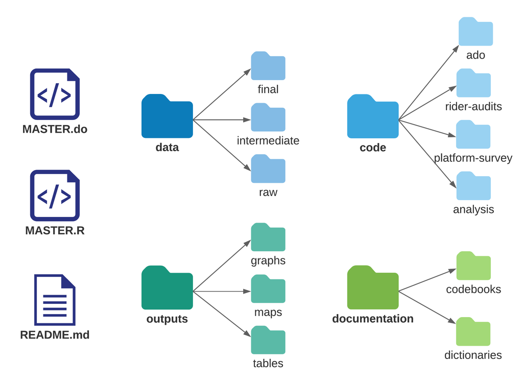

### Establishing common file formats

Each task in the research workflow has specific inputs and outputs which feed into one another. It is common, particularly when different tasks are performed by different people inside a team, for incompatibilities to be created. For example, if the Principal Investigators are writing a paper using LaTeX, exporting tables from statistical software into a `.csv` format will break the workflow. Therefore, it’s important to agree with your team on what tools will be used for what tasks, and where inputs and outputs will be stored, before you start creating them. Take into account ease of use for different team members, and keep in mind that learning how to use a new tool may require some time investment upfront that will be paid off as your project advances.

### Using version control

We recommend using a **version control system** to maintain control of file history and functionality. A good version control system tracks who edited each file and when, allows you to revert to previous versions, and provides a protocol for ensuring that conflicting versions are avoided. This is important, for example, for your team to be able to find the version of a presentation that you delivered to a donor, or to understand why the significance level of your estimates has changed. Everyone who has ever encountered a file named something like `final_report_v5_LJK_KLE_jun15.docx` can appreciate how useful such a system can be.

Most syncing services offer some kind of rudimentary version control; these are usually enough to manage changes to binary files (such as office documents) without needing to rely on dreaded filename-based versioning conventions. For code files, however, a more detailed version control system is usually desirable. We recommend using Git for version-control of all data work. Git documents changes to all **plaintext** files. Plaintext files include all code files, most raw outputs, and written outputs that use code languages, such as LaTeX files and many dynamic documents. Git tracks all the changes you make to each plaintext file, and allows you to go back to previous versions without losing the information on changes made. It also makes it possible to work on multiple parallel versions of a file, so you don’t risk breaking code for other team members as you try something new.

### Writing code that others can read

Good code is written in a way that is easily understood and run by others. Below we discuss a few crucial steps to code organization. They all come from the principle that code is an output by itself, not just a means to an end, and should be written thinking of how easy it will be for someone to read it later. At the end of this section, we include a template for a master script do-file in Stata, to provide a concrete example of the required elements and structure. Throughout this section, we refer to lines of this example do-file to give concrete examples of the required code elements, organization and structure.

Two types of comments should be included in the script itself. The first type of comment describes *what* is being done. This might be easy to understand from the code itself if you know the language well enough and the code is clear, but often it is still a great deal of work to reverse-engineer the code’s intent. Describing the task in plain English (or whichever language you use to communicate with your team) will make it easier for everyone to read and understand the code’s purpose. It can also help you organize your own work and ensure you are following logical steps. The second type of comment explains *why* the code is performing a task in a particular way. As you are writing code, you are making a series of decisions that (hopefully) make perfect sense to you at the time. These are often highly specialized and may exploit a functionality that is not obvious or has not been seen by others before. Well-commented code is in itself a great way to document your data work which someone can follow to understand anything from data cleaning decisions that make the published data differ from the original data to decisions on how indicators are constructed. Even you will probably not remember the exact choices that were made in a couple of weeks. Therefore, you must document your precise processes in your code.

Code files should be stored in an easy-to-find location and named in a meaningful way. Breaking your code into independently readable “chunks” is good practice for code organization. You should write each functional element as a chunk that can run completely on its own. This ensures that each code component is independent; it does not rely on a complex program state created by other code chunks that are not obvious from the immediate context. One way to do this is by creating sections in your script to identify where a specific task is completed. For example, if you want to find the line in your code where the directory is set, you can go straight to “`PART 2: Prepare folder paths and define programs`”, instead of reading line by line through the entire code.

RStudio makes it very easy to create sections, and it compiles them into an interactive script index for you. In Stata, you can use comments to create section headers (see line 27 of the example do-file), though they’re just there to make the reading easier and don’t have functionality. Since an index is not automated, create this manually in the code header by copying and pasting section titles (see lines 8-10 in the example do-file). You can then add and navigate through them using the `find` functionality. Since Stata code is harder to navigate, as you will need to scroll through the document, it’s particularly important to avoid writing very long scripts. Therefore, in Stata at least, we recommend breaking code tasks down into separate do-files, since there is no limit on how many you can have, how detailed their names can be, and no advantage to writing longer files. One reasonable rule of thumb is to not write do-files that have more than 200 lines. This is an arbitrary limit, just like the common practice of limiting code lines to 80 characters: it seems to be “enough but not too much” for most purposes.

### Demand for Safe Spaces Case Study: Writing Code That Others Can Read

To ensure that all team members were able to easily read and understand data work, *Demand for Safe Spaces* code files were extensively commented. Comments typically took the form of “what – why”: what is this section of code doing, and why is it necessary. The below snippet from a do-file cleaning one of the raw data files illustrates the use of comments:

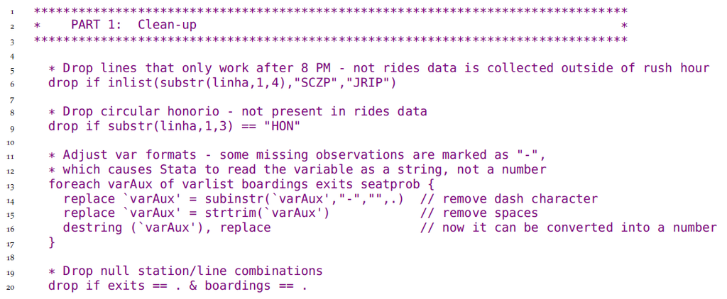

> The full code file is available at https://git.io/Jtgev

### Writing code that others can run

To bring all these smaller code files together, you must maintain a master script.[^72] A master script is the map of all your project’s data work which serves as a table of contents for the instructions that you code. Anyone should be able to follow and reproduce all your work from raw data to all outputs by simply running this single script. By follow, we mean someone external to the project who has the master script and all the input data can (i) run all the code and recreate all outputs, (ii) have a general understanding of what is being done at every step, and (iii) see how codes and outputs are related. The master script is also where all the settings are established, such as versions, folder paths, functions, and constants used throughout the project.

```stata
/*******************************************************************************
*                           TEMPLATE MASTER DO-FILE                            *
********************************************************************************
*                                                                              *
*   PURPOSE:     Reproduce all data work, map inputs and outputs,              *
*                facilitate collaboration                                      *
*                                                                              *
*   OUTLINE:     PART 1:  Set standard settings and install packages           *
*                PART 2:  Prepare folder paths and define programs             *
*                PART 3:  Run do-files                                         *
*                                                                              *
********************************************************************************
  PART 1:  Install user-written packages and harmonize settings
********************************************************************************/

    local user_commands ietoolkit iefieldkit //Add required user-written commands
    foreach command of local user_commands {
        cap which `command'
        if _rc == 111 ssc install `command'
    }

    *Harmonize settings across users as much as possible
    ieboilstart, v(13.1)
    `r(version)'

/*******************************************************************************
  PART 2:  Prepare folder paths and define programs
*******************************************************************************/

    * Research Assistant folder paths
    if "`c(username)'" == "ResearchAssistant" {
        global github      "C:/Users/RA/Documents/GitHub/d4di/DataWork"
        global dropbox     "C:/Users/RA/Dropbox/d4di/DataWork"
        global encrypted   "M:/DataWork/EncryptedData"
    }

    * Baseline folder globals
    global bl_encrypt       "${encrypted}/Round Baseline Encrypted"
    global bl_dt            "${dropbox}/Baseline/DataSets"
    global bl_doc           "${dropbox}/Baseline/Documentation"
    global bl_do            "${github}/Baseline/Dofiles"
    global bl_out           "${github}/Baseline/Output"

/*******************************************************************************
  PART 3: Run do-files
*******************************************************************************/

/*------------------------------------------------------------------------------
    PART 3.1:  De-identify baseline data
    REQUIRES:   ${bl_encrypt}/Raw Identified Data/D4DI_baseline_raw_identified.dta
    CREATES:    ${bl_dt}/Raw Deidentified/D4DI_baseline_raw_deidentified.dta
    IDS VAR:    hhid
----------------------------------------------------------------------------- */
    *Change the 0 to 1 to run the baseline de-identification dofile
    if (0) do "${bl_do}/Cleaning/deidentify.do"

/*------------------------------------------------------------------------------
    PART 3.2:  Clean baseline data
    REQUIRES:   ${bl_dt}/Raw Deidentified/D4DI_baseline_raw_deidentified.dta
    CREATES:    ${bl_dt}/Final/D4DI_baseline_clean.dta
                ${bl_doc}/Codebook baseline.xlsx
    IDS VAR:    hhid
----------------------------------------------------------------------------- */
    *Change the 0 to 1 to run the baseline cleaning dofile
    if (0) do "${bl_do}/Cleaning/cleaning.do"

/*-----------------------------------------------------------------------------
    PART 3.3:  Construct income indicators
    REQUIRES:   ${bl_dt}/Final/D4DI_baseline_clean.dta
    CREATES:    ${bl_out}/Raw/D4DI_baseline_income_distribution.png
                ${bl_dt}/Intermediate/D4DI_baseline_constructed_income.dta
    IDS VAR:    hhid
----------------------------------------------------------------------------- */
    *Change the 0 to 1 to run the baseline variable construction dofile
    if (0) do "${bl_do}/Construct/construct_income.do"
```

Try to create the habit of running your code from the master script. Creating “section switches” using macros or objects to run only the codes related to a certain task should always be preferred to manually open different scripts to run them in a certain order (see the `if (0)` switches in Part 3 of `stata-master-dofile.do` for one way of how to do this). Furthermore, running all scripts related to a particular task through the master whenever one of them is edited helps you identify unintended consequences of the changes you made. Say, for example, that you changed the name of a variable created in one script. This may break another script that refers to this variable. But unless you run both of them when the change is made, it may take time for that to happen, and when it does, it may take time for you to understand what’s causing an error. The same applies to changes in datasets and results.

To link code, data and outputs, the master script reflects the structure of the `DataWork` folder in code through globals (in Stata) or string scalars (in R); refer to lines 38-43 of the example do-file. These coding shortcuts can refer to subfolders, so that those folders can be referenced without repeatedly writing out their absolute file paths. Because the `DataWork` folder is shared by the whole team, its structure is the same in each team member’s computer. The only difference between machines should be the path to the project root folders, i.e. the highest-level shared folder. Depending on your software environment you may have multiple root folders. In a typical DIME project we have one Git root folder for our code, one sync software root folder for our de-identified data, and a third for our encrypted data. This is reflected in the master script in such a way that the only change necessary to run the entire code for a new team member is to change the path to the project root folders to reflect the file system and username; refer to lines 30-35 of the example do-file. The code in `stata-master-dofile.do` shows how folder structure is reflected in a master do-file. Because writing and maintaining a master script can be challenging as a project grows, an important feature of the `iefolder` is to write sub-master do-files and add to them whenever new subfolders are created in the `DataWork` folder.

In order to maintain well-documented and organized code, you should agree with your team on a plan to review code as it is written. Reading other people’s code is the best way to improve your coding skills. And having another set of eyes on your code will make you more comfortable with the results you find. It’s normal (and common) to make mistakes as you write your code. Reading it again to organize and comment it as you prepare it to be reviewed will help you identify them. Try to have a code review scheduled frequently, every time you finish writing a piece of code, or complete a small task. If you wait for a long time to have your code reviewed, and it gets too complex, preparation and code review will require more time and work, and that is usually the reason why this step is skipped. One other important advantage of code review is that making sure that the code is running properly on other machines, and that other people can read and understand the code easily, is the easiest way to be prepared in advance for a smooth project handover or for release of the code to the general public.

### Demand for Safe Spaces Case Study: Writing Code That Others Can Run

All code for the *Demand for Safe Spaces* study was organized to run from two master scripts, one Stata Master and one R Master. The master scripts were written such that any team member could run all project code by simply changing the top-level directory. Below is a snippet of the Stata Master:

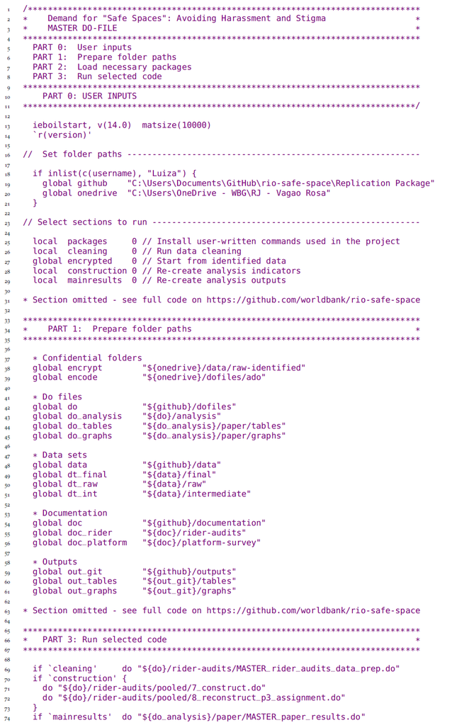

> The complete Stata master script can be found at https://git.io/JtgeT, and the R master at https://git.io/JtgeY.

## Preparing to handle confidential data ethically

Anytime you are working with original data in a development research project, you are almost certainly handling data that include **personally-identifying information (PII)**.[^73] PII is information which can, without any transformation or linkage, be used to identify individual people, households, firms, (or other units) in your data. Some examples of PII variables include names, addresses, and geolocations, email addresses, phone numbers, and bank accounts or other financial details. If you are working in a context or population that is either small, specific, or has extensive linkable data sources available to others, information like someone’s age and gender may be sufficient to disclose their identify, even though those variables would not be considered PII in general.

In a collaborative project, you will sometimes need to transfer and work with PII information, and sometimes you will prefer to remove or mask PII before transferring or working with data. There is no one-size-fits-all solution to determine what is PII, research teams have to use careful judgment in each case to avoid statistical disclosure.[^74] It is important to keep in mind that data privacy principles apply not only for the respondent giving you the information but also for their household members or other individuals who are included in the data.

In all cases where confidential information is involved, you must make sure that you adhere to several core principles. These include ethical approval, participant consent, data security, and participant privacy.[^75] If you are a US-based researcher, you will become familiar with a set of governance standards known as “The Common Rule.”[^76] If you interact with European institutions or persons, you will also become familiar with the General Data Protection Regulation (GDPR),[^77] a set of regulations governing **data ownership** and privacy standards. No matter who you are or what exact legal requirements you face, the core principles and practices you need to consider will always be similar.

### Seeking ethical approval

Most of the field research done in development involves human subjects.[^78] As a researcher, you are asking people to trust you with personal information about themselves: where they live, how rich they are, whether they have committed or been victims of crimes, their names, their national identity numbers, and all sorts of other data. PII data carries strict expectations about data storage and handling, and it is the responsibility of the research team to satisfy these expectations.[^79] Your donor or employer will most likely require you to hold a certification from a respected source.

For almost all such data collection and research activities, you will be required to complete some form of **Institutional Review Board (IRB)** process.[^80] Most commonly this consists of a formal application for approval of a specific protocol for consent, data collection, and data handling.[^81] Which IRB has authority over your project is not always apparent, particularly if some institutions do not have their own. It is customary to obtain an approval from a university IRB where at least one PI is affiliated, and if work is being done in an international setting, approval is often also required from an appropriate local institution subject to the laws of the country where data originates.

IRB approval should be obtained well before any data is acquired. IRBs may have infrequent meeting schedules or require several rounds of review for an application to be approved. If there are any deviations from an approved plan or expected adjustments, report these as early as possible so that you can update or revise the protocol. IRBs have the authority to retroactively deny the right to use data which was not acquired in accordance with an approved plan. This is extremely rare, but shows the seriousness of these considerations since the institution itself may face legal penalties if its IRB is unable to enforce them. As always, as long as you work in good faith, you should not have any issues complying with these regulations.

### Demand for Safe Spaces Example – Seeking Ethical Approval

The Duke University IRB reviewed and approved the protocol for all components of fieldwork for the *Demand for Safe Spaces* study (IRB number D0190). As one of the PIs was at Duke, and the World Bank does not have an IRB, Duke was the relevant institution in this case. The study was registered with the Duke IRB on September 2015. It was amended 4 times to reflect additions to the study design, such as an implicit association test (IAT) and a new survey. The IRB approval was renewed twice, in 2016 and 2017. Highlights from the study IRB protocols:

- *Voluntary study participation:* The study intervention was done through a smartphone application. Through the app, users were offered payment to complete a set of tasks while using the metro. The tasks involved answering questions at different moments of the trip (before boarding the train, during the ride, after leaving the train). At the start of each task, participants could review what it comprised and the exact payment value, then decide whether to accept the task or not. There was no obligation to complete any task.
- *Survey instruments:* translated drafts of all survey instruments were shared with the IRB
- *Privacy protection:* the intervention was done specialized mobile application developed by a partner technology company, which recruited users through social media. User data from the app was encrypted and stored in AWS. As per the user agreement, access to the raw data was restricted to employees of the tech company, using VPN and encrypted laptops. The tech company processed the raw data and released non-identifying data to the researchers, plus household coordinates (study participants provided informed consent to share this data).
- *Risk:* Participants were tasked with riding the public transport system in Rio De Janeiro. There is some general risk inherent in travel around Rio de Janeiro. However, the public transport system is widely used, and participants are expected to be those who regularly travel on the train. The assigned task may cause them to travel on a different route or at a different time than usual. Tasks are assigned around rush hour, so stations and trains will be crowded, which is expected to reduce risks. Note that half the riders on the system are women, and only a small fraction of the cars are reserved for women, so the task of riding the regular carriage will not require users to go into an all-male environment.
- *Ethical obligation:* when completing an assigned task, participants were asked whether they experienced any harassment. If harassment was reported, the app directed the participant to the platform guards to whom she could report harassment incidences (the guards are trained to respond to harassment reports), as well as to other resources available in the Rio area.

> Appendix C in the working paper discusses the ethics aspects of the study, including participant recruitment, informed consent and how reports of harassment were addressed: https://openknowledge.worldbank.org/handle/10986/33853

### Obtaining informed consent

One primary consideration of IRBs is the protection of the people about whom information is being collected and whose lives may be affected by the research design. Some jurisdictions (especially those who governed by EU law) view all personal data as intrinsically owned by the persons who they describe. This means that those persons have the right to refuse to participate in data collection before it happens, as it is happening, or after it has already happened. It also means that they must explicitly and affirmatively consent to the collection, storage, and use of their information for any purpose.

The development of appropriate consent processes is of primary importance. All survey instruments must include a module in which the sampled respondent grants informed consent to participate. Research participants must be informed of the purpose of the research, what their participation will entail in terms of duration and any procedures, any foreseeable benefits or risks, and how their identity will be protected.[^82] There are special additional protections in place for vulnerable populations, such as minors, prisoners, and people with disabilities, and these should be confirmed with relevant authorities if your research includes them.

### Demand for Safe Spaces Case Study: Obtaining Informed Consent

Participation in both the study intervention (assignments to take a specific Supervia ride) and the platform survey were fully voluntary, and both included informed consent. Per the informed consent protocols for the study intervention, participation in each assigned task was voluntary, and participants were paid for each ride they completed shortly after completion, regardless of the total number of rides they completed. Thus, participants could choose to stop participating at any time if they felt uncomfortable.

The consent statement participants were shown was the following:

> “If you choose to do this task, you will have to go to a Supervia station, ride the train, and answer questions about your experience on the train. You will have to ride the train for ___ minutes, and answering the questions will take about ten minutes. You will be paid at least ____ reais for the task, and possibly more. You will be able to review the payment for each task and option before deciding whether to do that task. You can choose during the task whether to ride either the women’s-only or the mixed carriage on the Supervia. Your responses to the task will not be identified in any way with you personally. The anonymous data will be shared with researchers at Duke University in the United States. You can choose to stop the task at any time. To get paid for this task, however, you have to finish the task.”

The sentence in italics was removed for the portion of the data collection in which participants were assigned to ride in a particular type of car; the rest of the consent statement applied to all tasks.

### Ensuring research subject privacy

In order to safeguard PII data and protect respondent privacy, you must set up a data protection protocol from the outset of a project. Secure data storage and transfer are ultimately your personal responsibility.[^83] Later chapters will discuss how to properly protect your data depending on which method you are using to acquire, store or share data. This section will only cover the computer setup you will need for any project. There are several components to this.

First, you need a system for managing strong and unique passwords for all accounts – including personal accounts like computer logins and email. This means that all your passwords should be long, not use common words and should not be reused for multiple accounts. The only way to make that practically feasible is to use a password manager.[^84] Most password managers also allow you to securely share passwords for shared accounts with your colleagues. Multi-factor authentication (sometimes called 2-step verification) is a secure alternative to passwords when available.

Second, machines that stores confidential data should not be connected to insecure physical or wireless networks, and when it is necessary to do so, they should use a VPN[^85] to connect to the internet. Furthermore, USB drives and other devices connecting over USB cables should not be connected to machines storing confidential data unless you know where the USB device came from and who has used it before you. Machines with confidential data should also be stored in a secure location when not in use.

Third, all confidential data must be encrypted at all times.[^86] When files are properly encrypted, the information they contain will be completely unreadable and unusable even if they were to be intercepted by a malicious “intruder” (an information-security term for any unauthorized information access) or accidentally made public. We will discuss implementations of encryption in more detail specific to different stages of data work in Chapter 4, but when setting up a software environment for you and your team, make sure that you have a solution for all parts of your workflow on all team members computers. You can encrypt your data at the disk (hard drive) level, called **full disk encryption** (FDE), or at the individual file or folder level, called **file system encryption** (FSE). When possible both should be applied, but our recommendation is that project teams set up data protection protocols using file system encryption as the main type of protection, and require all members that handle confidential data to use it.

Most implementations of FDE use your computer login password to prevent your files from ever being read by anyone but you. It is important to note that password protection alone is not sufficient. Password protection makes it more difficult for someone else to gain access to your files, but only encryption properly protects your data if someone manages to access your files anyway. Whenever FDE is available in your operating system it should always be enabled. FDE protects your data when encrypted just as well as FSE, but we recommend FSE due to the following disadvantages of FDE. First, FDE is implemented differently in different operating systems making it difficult to create useful instructions for all computer set-ups team members may use. Second, when FDE decrypts your disk, then all data on that disk is decrypted, even files you do not need to use at that time. Since most FDE systems automatically decrypt your full disk each time you log in, a malicious intruder that has gained access to your computer would have access to all your files. Third and perhaps most important, FDE cannot be used when sharing confidential data over insecure channels like file syncing services or email. So FDE would anyways have to be complimented with some other type of protection during collaboration.

When using FSE, instead of encrypting a full disk or drive, you create encrypted folders in which you can securely store confidential data. These encrypted folders protect your data when they are stored on your computer but can also be used to securely transfer data over insecure channels like file syncing services and email. Encrypted folders in FSE are only decrypted when you need that specific folder to be decrypted. That means that a malicious intruder that has gained access to your computer only gains access to the folders you have decrypted while your computer was compromised. Folders you rarely or never decrypt therefore remain protected even if someone gains access to your computer. DIME uses VeraCrypt for FSE, and our protocols are available as part of the DIME Research Standards.[^87] VeraCrypt is free of charge and available for Windows, MacOS, and Linux. While some details are different across platforms, the encryption will be implemented the same way for all team members.

Regardless of whether you use full disk encryption or file system encryption, it is important to remember that encryption provides no protection when your data is decrypted. Therefore, you should always log out from your computer when you are not using it, and only keep folders with confidential data decrypted when you need exactly those files. The latter is only possible when you are using FSE.

Handling confidential data properly will always add to your workload. The easiest way to reduce that work load is to handle it as rarely as possible. Whenever our research design allows us to, we should not work with confidential data at all, and not collect it or ask for it in the first place. Even when we do need confidential data for some aspect of our research, it is almost never the case that we need it for *all* aspects of our data. It is often very simple to conduct planning and analytical work using a subset of the data that does not include this type of information. Therefore we recommend that all projects plan a workflow with a version of the data where confidential data has been removed and always use that dataset when possible.

Note that it is in practice impossible to **anonymize** data. There is always some statistical chance that an individual’s identity will be re-linked to the data collected about them – even if that data has had all directly identifying information removed – by using some other data that becomes identifying when analyzed together. For this reason, we recommend de-identification in two stages. The **initial de-identification** process strips the data of direct identifiers as early in the process as possible, to create a working de-identified dataset that can be shared *within the research team* without the need for encryption. This data set should always be used when possible. The **final de-identification** process involves making a decision about the trade-off between risk of disclosure and utility of the data before publicly releasing a dataset.[^88]

Finally, it is essential to have an end-of-life plan for data even before it is acquired.[^89] This includes plans for how to transfer access and control to a new person joining the team, and how to revoke that access when someone is leaving the team. It should also include a plan for how the confidential data should be deleted. Every project should have a clear data retention and destruction plan. After a project is completed and its de-identified data has been made available as a part of data publication, research teams should not retain confidential data indefinitely.

### Demand for Safe Spaces Example: Ensuring Research Subject Privacy

The *Demand for Safe Spaces* team adopted the following data security protocols:

- All confidential data was stored in a World Bank OneDrive folder The World Bank One Drive has been set up by WB IT to be more secure than regular OneDrive and is the recommended institutional solution for storing confidential data.
- Access to the confidential data was limited to the Research Analyst and the Research Assistant working on the data cleaning.
- All de-identified data used for the analysis was stored in the synchronized folder shared by the full research team (in this case, using Dropbox).
- Indirect identifiers such as demographic variables and labels to train lines and stations were removed from the data before it was published to the Microdata Catalog.

## Looking ahead

With your code environment established, you will have a firm idea about how you are going to handle the data and code that you receive and create throughout the research process. This structure should prepare you to work collaboratively, to share code and data across machines and among team members, and to document your work as a group. With an organization plan and plans to to version-control and back up files, you are ready to handle materials ethically and securely. You should also have secured the approvals needed for any planned work. You are now ready to translate your project’s research design into a measurement framework to answer your research questions. In the next chapter, we will outline how to prepare the essential elements of research data. You will learn how to map out your project’s data needs according to both the research design and the planned creation and use of data across the project timeline.

# 3 Establishing a measurement framework

The first step in the data workflow is to establish a measurement framework. This requires understanding your project’s data requirements and how to structure the required data to answer the research questions. Setting up the measurement framework involves more than simply listing the key outcome variables. You also need to understand how to structure original data, to determine how different data sources connect together, and to create tools to document these decisions and communicate them to the full research team. In this chapter we will show how to develop this framework, and hope to convince you that planning in advance both saves time and increases research quality.

The first section of this chapter introduces the *DIME Data Map Template*. The template includes a data linkage table, master datasets, and data flowcharts. These tools are used to communicate the project’s data requirements across the team and over time. The second section discusses how to translate your project’s research design into data needs. It provides examples on the specific data required by common impact evaluation research designs, and how to document the linkage between research design and data sources in our data map template. The final section links the measurement framework to the reproducibility and credibility pillars introduced in Chapter 1. It covers how to reproducibly generate research design variables and how to user power calculations and randomization inference to assess credibility.

## Documenting data needs

Most projects require more than one data source to answer a research question. These could be data from multiple survey rounds, data acquired from different partners (such as administrative data, implementation data, sensor data), technological tools like satellite imagery or web scraping, or complex combinations of these and other sources.[^90] However your study data is structured, you need to know how to link data from all sources and analyze the relationships between units to answer your research questions. You might think that you are able to keep all the relevant details in your head, but the whole research team is unlikely to have the same understanding, over the whole lifecycle of the project, of the relationship between all required datasets. To make sure that the full team shares the same understanding, we recommend creating a **data map**.[^91] The purpose of the data map is to make sure that you have all data that you need to answer the research questions in your research design, well before starting the analysis process described in Chapter 6. It is also useful documentation for the project. The process of drafting the data map is a useful opportunity for principal investigators to communicate their vision of the data structure and requirements, and for research assistants to communicate their understanding of that vision. Our recommended best practice is that the data map is completed before any data is acquired and that it is made a part of the pre-registration of the study. However, in practice many research projects evolve as new data sources, observations, and research questions arise, and then it is important that each component of the Data Map is continuously maintained and updated.

DIME’s data map template has three components: one *data linkage table*, one or several *master datasets* and one or several *data flowcharts*. The **data linkage table**[^92] lists all the raw datasets that will be used in the project, what data sources they are created from, and how they relate to each other. For each **unit of observation**[^93] in the data linkage table, as well for each unit of analysis you plan to use, you will create and maintain a **master dataset**[^94], listing all observations of that unit relevant to the project. Finally, using these two resources you will create **data flowcharts**,[^95] describing how the raw datasets and master datasets are to be combined and manipulated to create analysis datasets. Each component will be discussed in more detail below.

In order to map measurement frameworks into data needs, we find it helpful to distinguish between two types of variables: variables that tie your research design to the observations in the data, which we call *research design variables*; and variables that correspond to observations of the real world, which we call *measurement variables*. *Research design variables* map information about your research subjects to the research design. Often, these variables have no meaning outside the research project, for example ID variables and treatment status. Others will be observations from the real world, but only those that determines how each specific research unit should be handled during the analysis, for example treatment uptake and eligibility status. *Measurement variables*, on the other hand, are real world measures that are not determined by the research team. Examples include characteristics of the research subject, outcomes of interest, and control variables among many others.

### Developing a data linkage table

To create a data map according to DIME’s template, the first step is to create a **data linkage table** by listing all the data sources you know you will use in a spreadsheet, and the raw datasets that will be created from them. If one source of data will result in two different raw datasets, then list each dataset on its own row. For each dataset, list the unit of observation and the name of the **project ID**[^96] variable for that unit of observation. It is important to include both plain-language terminology as well as technical file and variable names here. For example, the `hh_baseline2020_listmap.csv` dataset may be called the “Baseline Household Listing” data; it may be identified by the `hh_id` variable and said to be identified at the “Household” level. Having the plain-language terminology here early in the project allows you to use these titles unambiguously in communication.

The data linkage table will therefore help you plan out how you will identify each unit of observation in your data. When you list a dataset in the data linkage table – which should be done before that data source is acquired – you should make sure that the data will be fully and uniquely identified by the project ID, or make a plan for how the new dataset will be linked to the project ID. It is very labor-intensive to work with a dataset that does not have an unambiguous way to link to the project ID, and it is a major source of error.[^97]

The data linkage table should indicate whether datasets can be merged one-to-one (for example, merging baseline and endline datasets that use the same unit of observation), or whether two datasets need to be merged many-to-one (for example, school administrative data merged with student data). Your data map must indicate which ID variables can be used – and how – when merging datasets. The data linkage table is also a great place to list other metadata, such as the source of your data, its backup locations, the nature of the data license, and so on.

### Constructing master datasets

The second step in creating a data map is to create one **master dataset** for each unit of observation that will be used in any research activity. Examples of such activities are data collection, data analysis, sampling, and treatment assignment. The master dataset is the authoritative source of the project ID and all research design variables for the corresponding unit of observation, such as sample status and treatment assignment. Therefore, the master dataset serves as an unambiguous method of mapping the observations in the data to the research design. A master dataset should not include any measurement variables. Research design variables and measurement variables may come from the same source, but should not be stored in the same way. For example, if you acquire administrative data that both includes information on eligibility for the study (research design variables) and data on the topic of your study (measurement variables), the data should be processed such that research design variables are stored in the master dataset, while measurement variables should be stored separately and prepared for analysis as described in Chapter 5.

Each master dataset is to be the authoritative source for how all observations at that unit of analysis are identified. This means that the master datasets should include identifying information such as names, contact information, and the project ID. The project ID is the ID variable used in the data linkage table, and is therefore how observations are linked across datasets. Your master dataset may list alternative IDs that are used, for example, by a partner organization. However, you must not use such an ID as your project ID, as you would then not be in control over who can re-identify data. The project ID must be created by the project team, and the linkage to direct identifiers should only be known to people listed on the IRB. Your master dataset serves as the linkage between all other identifying information and your project ID. Since your master dataset is full of identifying information, it must always be encrypted. If you receive a dataset with an alternative ID, you should replace it with your project ID as a part of de-identification (see Chapter 5 and Chapter 7 for more on de-identification). The alternative ID should be stored in your master dataset so it may be linked back to your data using the project ID if ever needed. Any dataset that needs to retain an alternative ID for any reason should be treated as confidential data; it should always be encrypted and never published.

The starting point for the master dataset is typically a sampling frame (more on sampling frames later in this chapter). However, you should continuously update the master dataset with all observations ever encountered in your project, even if those observations are not eligible for the study. Examples include new observations listed during monitoring activities or observations that are connected to respondents in the study, for example in a social network module. This is useful because, if you ever need to perform a record linkage such as a fuzzy match on string variables like proper names, the more information you have the fewer errors you are likely to make. If you ever need to do a fuzzy match, you should always do that between the master dataset and the dataset without an unambiguous identifier.[^98] You should not begin data cleaning or analysis until you have successfully merged the project IDs from the master dataset. When adding new observations to the master datasets, always convince yourself beyond reasonable doubt that the new observation is indeed a new observation. Sometimes you will encounter different spellings in identifiers and identifiers such as addresses may become outdated.

### Creating data flowcharts

The third and final step in creating the data map is to create **data flowcharts**. Each analysis dataset (see Chapter 6 for discussion on why you likely need multiple analysis datasets) should have a data flowchart showing how it was created. The flowchart is a diagram where each starting point is either a master dataset or a dataset listed in the data linkage table. The data flowchart should include instructions on how the datasets can be combined to create the analysis dataset. The operations used to combine the data could include: appending, one-to-one merging, many-to-one or one-to-many merging, collapsing, or a broad variety of others. You must list which variable or set of variables should be used in each operation, and note whether the operation creates a new variable or combination of variables to identify the newly linked data. Datasets should be linked by project IDs when possible (exceptions are time variables in longitudinal data, and sub-units like farm plots that belong to farmers with project IDs). Once you have acquired the datasets listed in the flowchart, you can add to the data flowcharts the number of observations that the starting point dataset has and the number of observation each resulting datasets should have after each operation. This is a great method to track attrition and to make sure that the operations used to combine datasets did not create unwanted duplicates or incorrectly drop any observations.

The information that goes into the data flowcharts can be expressed in text, but our experience is that diagrams are the most efficient way to communicate this information across a team. A data flowchart can be created in a flowchart drawing tool (there are many free alternatives online) or by using the shapes or SmartArt tools in, for example, Microsoft Office. You can also do this simply by drawing on a piece of paper and taking a photo, but we recommend a digital tool so that flowcharts can easily be updated over time if needed. As with the data linkage table, you should include both technical information and plain-language interpretations of the operations that are done and the data that is created. These will help readers understand the complex data combinations that often result from merges and appends, such as panel datasets like “person-year” structures and multi-level data like “district-school-teacher-student” structures.

## Translating research design to data needs

An important step in translating the research design to specific data structure is to determine which research design variables you will need in the data analysis to infer what differences in measurement variables are attributable to your research design. These data needs should be expressed in your data map by listing the data source for each variable in the data linkage table, by adding columns for them in your master dataset (the master dataset might not have any observations yet; that is not a problem), and by indicating in your data flowcharts how they will be merged to the analysis data. It is important you do this before acquiring any data, to make sure that the data acquisition activities described in chapter 4 will generate the data needed to answer your research questions.

As DIME primarily works on impact evaluations, we focus our discussion here on research designs that compare a group that received some kind of **treatment**[^99] against a **counterfactual**.[^100] The key assumption is that each person, facility, or village (or whatever the unit of treatment is) had two possible states: their outcome if they did receive the treatment and their outcome if they did not receive that treatment. The average impact of the treatment,[^101] is defined as the difference between these two states averaged over all units.

However, we can never observe the same unit in both the treated and untreated state simultaneously, so we cannot calculate these differences directly. Instead, the treatment group is compared to a control group that is statistically indistinguishable, which is often referred to as achieving **balance** between two or more groups. DIME Analytics maintains a Stata command to standardize and automate the creation of well-formatted balance tables: `iebaltab`.[^102] Each research design has a different method for identifying and balancing the counterfactual group. The rest of this section covers how research data requirements differ between those different methods. What does not differ, however, is that these data requirements are all research design variables. And that the research design variables discussed below should always be included in the master dataset. You will often have to merge the research design variables to other datasets, but that is an easy task if you created a data linkage table.

We assume you have a working familiarity with the research designs mentioned here. You should reference our **Research Design Appendix**, where you will find more details and specific references for common impact evaluation designs.

### Applying common research designs to data

In **experimental research designs**, such as **randomized control trials (RCTs)**,[^103] the research team determines which members of the studied population will receive the treatment. This is typically done by a randomized process in which a subset of the eligible population is randomly assigned to receive the treatment (see later in this chapter for how to implement this). The intuition is that if everyone in the eligible population is assigned at random to either the treatment or control group, then the two groups will, on average, be statistically indistinguishable. Randomization makes it generally possible to obtain unbiased estimates of the effects that can be attributed to a specific program or intervention: in a randomized trial, the expected spurious correlation between treatment and outcomes will approach zero as the sample size increases.[^104] The randomized assignment should be done using data from the master dataset, and the result should be saved back to the master dataset, before being merged to other datasets.

**Quasi-experimental research designs**,[^105] by contrast, are based on events not controlled by the research team. Instead, they rely on “experiments of nature”, in which natural variation in exposure to treatment can be argued to approximate deliberate randomization. You must have a way to measure this natural variation, and how the variation is categorized as outcomes of a naturally randomized assignment must be documented in your master dataset. Unlike carefully planned experimental designs, quasi-experimental designs typically require the luck of having access to data collected at the right times and places to exploit events that occurred in the past. Therefore, these methods often use either secondary data, including administrative data or other classes of routinely-collected information, and it is important that your data linkage table documents how this data can be linked to the rest of the data in your project.

No matter the design type, you should be very clear about which data points you observe or collect are research design variables. For example, **regression discontinuity (RD)**[^106] designs exploit sharp breaks or limits in policy designs.[^107] The cutoff determinant, or running variable, should be saved in your master dataset. In **instrumental variables (IV)**[^108] designs, the **instruments** influence the *probability* of treatment.[^109] These research design variables should be collected and stored in the master dataset. Both the running variable in RD designs and the instruments in IV designs, are among the rare examples of research design variables that may vary over time. In such cases your research design should ex-ante clearly indicate what point of time they will be recorded, and this should be clearly documented in your master dataset.

In **matching** designs, observations are often grouped by a strata, grouping, index, or propensity score.[^110] Like all research design variables, the matching results should be stored in the master dataset. This is best done by assigning a matching ID to each matched pair or group, and create a variable in the master dataset with the matching ID each unit belongs to.[^111] In all these designs, fidelity to the design is important to record as well.[^112] A program intended for students that scored under 50% on a test might have some cases where the program is offered to someone that scored 51% at the test, or someone that scored 49% at the might decline to participate in the program. Differences between assignments and realizations should also be recorded in the master datasets.

### Including multiple time periods

Your data map should also take into consideration whether your project uses data from one time period or several. A study that observes data in only one time period is called a **cross-sectional study**. Observations over multiple time periods, referred to as **longitudinal data**, can consist of either **repeated cross-sections** or **panel data**. In repeated cross-sections, each successive round of data collection uses a new random sample of observations from the treatment and control groups, but in a panel data study the same observations are tracked and included each round.[^113] If each round of data collection is a separate activity, then they should be treated as separate sources of data and get their own row in the data linkage table.

If the data is generated continuously, or acquired at frequent intervals, then it can be treated as a single data source. When panel data is acquired in discreet batches, the data linkage table must document how the different rounds will be merged or appended. You must keep track of the *attrition rate* in panel data, which is the share of observations not observed in follow-up data. It is common that the observations not possible to track can be correlated with the outcome you study.[^114] For example, poorer households may live in more informal dwellings, patients with worse health conditions might not survive to follow-up, and so on. If this is the case, then your results might only be an effect of your remaining sample being a subset of the original sample that were better or worse off from the beginning. You should have a variable in your master dataset that indicates attrition. A balance check using the attrition variable can provide insights as to whether the lost observations were systematically different compared to the rest of the sample.

### Incorporating monitoring data

Therefore, you must acquire monitoring data that tells you how well the realized treatment implementation in the field corresponds to your intended treatment assignment, for nearly all experimental research designs. While monitoring data has traditionally been collected by sending someone to the field , it is increasingly common to collect monitoring data remotely. Some examples of remote monitoring include: local collaborators uploading geotagged images for visible interventions (such as physical infrastructure), installing sensors to broadcast measurements (such as air pollution or waterflow), distributing wearable devices to track location or physical activity (such as fitbits), or applying image recognition to satellite data. In-person monitoring activities are often preferred but cost and travel dangers, such as conflicts or disease outbreaks, make remote monitoring innovations increasingly appealing. If cost alone is the constraint, consider sampling a subset of the implementation area to monitor in-person. This may not be detailed enough to be used as a control in your analysis, but it will still provide a means to estimate the validity of your research design assumptions.

Linking monitoring data to the rest of the data in your project is often complex and a major source of errors. Monitoring data is rarely received in the same format or structure as your research data.[^115] For example, you may receive a list of the names of all people who attended a training, or administrative data from a partner organization without a proper identifier. In both those cases it can be difficult to ensure a one-to-one match between units in the monitoring data and the master datasets. Planning ahead, and collaborating closely with the implementing organization from the outset of the project, is the best way to avoid these difficulties. Often, it is ideal for the research team to prepare forms (paper or electronic) for monitoring, preloading with names of sampled individuals, or ensuring that there is a consistent identifier that is directly linkable to the project ID. If monitoring data is not handled carefully, you risk ending up with poor correlation between treatment uptake and treatment assignment, without a way to tell if the poor correlation is just a result of poor matching of the monitoring data or a meaningful implementation problem.

## Creating research design variables by randomization

Random sampling and random treatment assignment are two core research activities that generate important research design variables. Random sampling and random treatment assignment directly determine the set of individuals who will be observed and what their status will be for the purpose of effect estimation. **Randomization**[^116] is used to ensure that a sample is representative and that treatment groups are statistically indistinguishable.

Randomization in statistical software is non-trivial and its mechanics are unintuitive for the human brain. The principles of randomization we will outline apply not just to random sampling and random assignment, but to all statistical computing processes that have random components such as simulations and bootstrapping. Furthermore, all random processes introduce statistical noise or uncertainty into estimates of effect sizes. Choosing one random sample from all the possibilities produces some probability of choosing a group of units that are not, in fact, representative. Similarly, choosing one random assignment produces some probability of creating groups that are not good counterfactuals. *Power calculation* and *randomization inference* are the main methods by which these probabilities of error are assessed. These analyses are particularly important in the initial phases of development research – typically conducted before any data acquisition or field work occurs – and have implications for feasibility, planning, and budgeting.

### Randomizing sampling and treatment assignment

**Sampling** is the process of randomly selecting observations from a list of individuals to create a representative or statistically similar sub-sample. This process can be used, for example, to select a subset from all eligible units to be included in data collection when the cost of collecting data on everyone is prohibitive.[^117] But it can also be used to select a sub-sample of your observations to test a computationally heavy process before running it on the full data. **Randomized treatment assignment** is the process of assigning observations to different treatment arms. This process is central to experimental research design. Most of the code processes used for randomized assignment are the same as those used for sampling, since it is also a process of randomly splitting a list of observations into groups. Where sampling determines whether a particular individual will be observed at all in the course of data collection, randomized assignment determines if each individual will be observed as a treatment observation or used as a counterfactual.

The list of units to sample or assign from may be called a **sampling universe**, a **listing frame**, or something similar. The starting point for randomized sampling or assignment should be a **master dataset** in almost all cases, and the result of the randomized process should always be saved in the master dataset before it is merged to any other data. Example of exceptions when this cannot start from a master dataset are: sampling done in real time, such as randomly sampling patients as they arrive at a health facility, and treatment assignment done through an in-person lottery. In those cases, it is important that you collect enough data during the real time sampling, or take care to prepare the inputs for the lottery such that you can add these individuals to your master dataset afterwards.

### Programming reproducible random processes

For statistical programming to be reproducible, you must be able to re-obtain its exact outputs in the future.[^119] We will focus on what you need to do to produce truly random results for your project, to ensure you can get those results again. This takes a combination of strict rules, solid understanding, and careful programming. This section introduces strict rules: these are non-negotiable (but thankfully simple). Stata, like most statistical software, uses a **pseudo-random number generator**[^120] which, in ordinary research use, produces sequences of number that are as good as random.[^121] However, for *reproducible* randomization, we need two additional properties: we need to be able to fix the sequence of numbers generated and we need to ensure that the first number is independently randomized. In Stata, this is accomplished through three concepts: **versioning**, **sorting**, and **seeding**. We again use Stata in our examples, but the same principles translate to all other programming languages.

**Rule 1: Versioning** requires using the same version of the software each time you run the random process. If anything is different, the underlying list of random numbers may have changed, and it may be impossible to recover the original result. In Stata, the `version` command ensures that the list of random numbers is fixed.[^122] The `ieboilstart` command in `ietoolkit` provides functionality to support this requirement.[^123] We recommend you use `ieboilstart` at the beginning of your master do-file.[^124] Note that testing your do-files without running them via the master do-file may produce different results, since Stata’s `version` setting expires after each time you run your do-files.

**Rule 2: Sorting** requires that the order of the actual data that the random process is run on is fixed. Because random numbers are assigned to each observation row-by-row starting from the top row, changing their order will change the result of the process. In Stata, we recommend using `isid [id_variable], sort` to guarantee a unique sorting order. This command does two things. First it tests that all observations have unique values in the sort variable, as duplicates would cause an ambiguous sort order. If all values are unique, then the command sorts on this variable guaranteeing a unique sort order. It is a common misconception that the `sort, stable` command may also be used, but by itself it cannot guarantee an unambiguous sort order and is therefore not appropriate for this purpose. Since the exact order must be unchanged, the underlying data itself must be unchanged as well between runs. This means that if you expect the number of observations to change (for example to increase during ongoing data collection), your randomization will not be reproducible unless you split your data up into smaller fixed datasets where the number of observations does not change. You can combine all those smaller datasets after your randomization.

**Rule 3: Seeding** requires manually setting the start point in the list of pseudo-random numbers. A seed is just a single number that specifies one of the possible start points. It should be at least six digits long and you should use exactly one unique, different, and randomly created seed per randomization process.[^125] In Stata, `set seed [seed]` will set the generator to the start point identified by the seed. In R, the `set.seed` function does the same. To be clear: you should not set a single seed once in the master do-file, but instead you should set a new seed in code right before each random process. The most important thing is that each of these seeds is truly random, so do not use shortcuts such as the current date or a seed you have used before. You should also describe in your code how the seed was selected.

As discussed above, at times it will not be possible to use a master dataset for randomized sampling or treatment assignment (examples were sampling patients on arrival or live lotteries). In addition to presenting challenges with matching, these methods typically do not leave a record of the randomization, and as such are never reproducible. However, you can often run your randomization in advance even when you do not have list of eligible units in advance. Let’s say you want to, at various health facilities, randomly select a sub-sample of patients as they arrive. You can then have a pre-generated list with a random order of “in sample” and “not in sample”. Your field staff would then go through this list in order and cross off one randomized result as it is used for a patient.

This is especially beneficial if you are implementing a more complex randomization. For example, a hypothetical research design may call for enumerators to: (1) sample 10% of people observed in a particular location; (2) show a video to 50% of the sample; (3) administer a short questionnaire to 80% of all those sampled and (4) administer a longer questionnaire to the remaining 20%, with the questionnaire mix equal between those who were shown the video and those that were not. In real-time, such a complex randomization is much more likely to be implemented correctly if your field staff simply can follow a list with the randomized categories where you are in control of the pre-determined proportions and the random order. This way, you can also control with precision how these categories are evenly distributed across all the locations where you plan to conduct this research.

Finally, if this real-time randomization implementation is done using survey software, then the pre-generated list of randomized categories can be preloaded into the questionnaire. Then the field team can follow a list of respondent IDs that are randomized into the appropriate categories, and the survey software can show a video and control which version of the questionnaire is asked. This way, you reduce the risk of errors in field randomization.

### Implementing clustered or stratified designs

**Stratification** breaks the full set of observations into subgroups before performing randomized assignment within each subgroup.[^130] The subgroups are called **strata**. This ensures that members of every subgroup are included in all groups of the randomized assignment process, or that members of all groups are observed in the sample. Without stratification, it is possible that the randomization would put all the members of a subgroup into just one of the treatment arms, or fail to select any of them into the sample. For both clustering and stratification, implementation is nearly identical in both random sampling and random assignment.

Clustering is procedurally straightforward in Stata, although it typically needs to be performed manually. To cluster a sampling or randomized assignment, randomize on the master dataset for the unit of observation of the cluster, and then merge the results to the master dataset for the unit of analysis. This is a many-to-one merge and your data map should document how those datasets can be merged correctly. If you do not have a master dataset yet for the unit of observation of the cluster, then you first have to create that and update your data map accordingly. When sampling or randomized assignment is conducted using clusters, the clustering variable should be clearly identified in the master dataset for the unit of analysis since it will need to be used in subsequent statistical analysis. Namely, standard errors for these types of designs must be clustered at the level at which the randomization was clustered.[^131] This accounts for the design covariance within the cluster – the information that if one individual was observed or treated there, the other members of the clustering group were as well.

Although procedurally straightforward, implementing stratified designs in statistical software is prone to error. Even for a simple multi-armed design, the basic method of randomly ordering the observations will often create very skewed assignments.[^132] The user-written `randtreat` command properly implements stratification.[^133] The options and outputs (including messages) from the command should be carefully reviewed so that you understand exactly what has been implemented. Notably, it is extremely hard to target precise numbers of observations in stratified designs, because exact allocations are rarely round fractions and the process of assigning the leftover “misfit” observations imposes an additional layer of randomization above the specified division.

### Performing power calculations

Random sampling and treatment assignment are noisy processes: it is impossible to predict the result in advance. By design, we know that the exact choice of sample or treatment will be uncorrelated with our key outcomes, but this lack of correlation is only true “in expectation” – that is, the noise component of the correlation between randomization and outcome will only be zero on average across a large number of randomized trials. In any *particular* randomization, the correlation between the sampling or randomized assignments and the outcome variable is guaranteed to be *nonzero*: this is called the **in-sample** or **finite-sample correlation**.

Since we know that the true correlation (over the “population” of potential samples or randomized assignments) is zero, we think of the observed correlation as an **error**. In sampling, we call this the **sampling error**, and it is defined as the difference between a true population parameter and the observed mean due to chance selection of units.[^134] In randomized assignment, we call this the **randomization noise**, and define it as the difference between a true treatment effect and the estimated effect due to placing units in groups. The intuition for both measures is that from any group, you can find some possible subsets that have higher-than-average values of some measure; similarly, you can find some that have lower-than-average values. Your random sample or treatment assignment will fall in one of these categories, and we need to assess the likelihood and magnitude of this occurrence. *Power calculation* and *randomization inference* are the two key tools to doing so.[^135]

**Power calculations** report the likelihood that your experimental design will be able to detect the treatment effects you are interested in given these sources of noise. This measure of **power** can be described in various different ways, each of which has different practical uses. The purpose of power calculations is to identify where the strengths and weaknesses of your design are located, so you know the relative tradeoffs you will face by changing your randomization scheme for the final design. It is important to consider take-up rates and attrition when doing power calculations; incomplete take-up will significantly reduce power, understanding what minimum level of take-up is required can help guide field operations (for this reason, monitoring take-up in real-time is often critical).

The **minimum detectable effect (MDE)**[^136] is the smallest true effect that a given research design can reliably detect. This is useful as a check on whether a study is worthwhile. If, in your field, a “large” effect is just a few percentage points or a small fraction of a standard deviation, then it is nonsensical to run a study whose MDE is much larger than that. This is because, given the sample size and variation in the population, the effect needs to be much larger to possibly be statistically detected, so such a study would never be able to say anything about the effect size that is practically relevant. Conversely, the **minimum sample size** pre-specifies expected effect sizes and tells you how large a study’s sample would need to be to detect that effect, which can tell you what resources you would need to implement a useful study.

**Randomization inference**[^137] is used to analyze the likelihood that the randomized assignment process, by chance, would have created a false treatment effect as large as the one you estimated. Randomization inference is a generalization of placebo tests, because it considers what the estimated results would have been from a randomized assignment that did not in fact happen in reality. Randomization inference is particularly important in quasi-experimental designs and in small samples, where the number of possible *randomizations* is itself small. Randomization inference can therefore be used proactively during experimental design, to examine the potential spurious treatment effects your exact design is able to produce. If there is significant heaping at particular result levels, or if results seem to depend dramatically on the outcomes for a small number of individuals, randomization inference will flag those issues before the experiment is fielded and allow adjustments to the design to be made.

## Looking ahead

This chapter introduced the DIME Data Map template, a toolkit to documents your data acquisition plan and how each data source relates to the design of your study. The data map contains research design variables and the instructions for using them in combination with measurement variables, which together will form the dataset(s) for your analytical work. We then discussed ways for you to use this planning data to inform and execute research design tasks, such as randomized sampling and assignment, and to produce concrete measures of whether the project design is sufficient to answer the research questions you pose. In the next chapter, we will turn to the first step in actually answering those questions – data acquisition. The next chapter will detail the processes of obtaining original data, whether you are collecting it yourself or receiving it from another entity.

# 4 Acquiring development data

Many research questions require the team to acquire original data, because no source of publicly available data addresses the inputs or outcomes of interest for the relevant population. Data acquisition can take many forms, including: primary data generated through surveys; private sector partnerships granting access to new data sources, such as administrative and sensor data; digitization of paper records, including administrative data; web scraping; primary data capture by unmanned aerial vehicles or other types of remote sensing; or novel integration of various types of datasets, such as combining survey and sensor data. Much of the recent push toward credibility in the social sciences has focused on analytical practices. However, credible development research depends, first and foremost, on the quality of the acquired data. Clear and careful documentation of the data acquisition process is essential for research reproducibility.

This chapter covers reproducible data acquisition, special considerations for generating high-quality survey data, and protocols for safely and securely handling confidential data. The first section discusses reproducible data acquisition: how to establish and document your right to use the data. This applies to all original data, whether collected for the first time through surveys or sensors or acquired through a unique partnership. The second section goes into detail on data acquisition through surveys, as this process is typically more involved than acquisition of secondary data, and has more in-built opportunities for quality control. It provides detailed guidance on the electronic survey workflow, from designing electronic survey instruments to monitoring data quality once fieldwork is ongoing. The final section discusses safe data handling, providing guidance on how to receive, transfer, store, and share confidential data. Secure file management is a basic requirement to comply with the legal and ethical agreements that allow access to personal information for research purposes.

## Acquiring data ethically and reproducibly

Clearly establishing and documenting data access is critical for reproducible research. This section provides guidelines for establishing data ownership, receiving data from development partners, and documenting the research team’s right to use the data. It is the researchers’ responsibility to respect the rights of people who own the data and the people who are described by it; but also to make sure that information is as available and accessible as possible. These twin responsibilities can and do come into tension, so it is important to be fully informed about what other researchers are doing and to fully inform other researchers of what you are doing. Writing down and agreeing to specific details is a good way of doing that.

### Determining data ownership

Before acquiring any data, it is critical to establish data ownership. Data ownership[^138] can sometimes be challenging to establish, as various jurisdictions have differing laws regarding data and information, and the research team may have their own information regulations.[^139] In some, data is implicitly owned by the people who it is about. In others, it is owned by the people who collected it. In still more, it is highly unclear and there are varying norms. The best approach is always to consult with a local partner, and enter into specific legal agreements establishing ownership, access, and publication rights. This is particularly critical where confidential data is involved – that is, when people are disclosing information to you that you could not obtain simply by observation or through public records.

If the research team is requesting access to existing data, they must enter into data licensing agreements to access the data and publish research outputs based on it. These agreements should make clear from the outset whether and how the research team can make the original data public, or publish any portion or **derivative** of the data.[^140] If the data is publicly accessible, this may be as simple to agreeing to terms of use on the website where the data can be downloaded. If it is original data that is not yet publicly accessible, the process is typically more complex and requires a documented legal agreement or memorandum of understanding.

If the research team is generating data directly, such as survey data, it is important to clarify up front who owns the data, and who will have access to it. These details need to be shared with respondents when they are offered the opportunity to consent to participate in the study. If the research team is not collecting the data directly – for example, if a government, private company, or research partner is doing the data collection – make sure that you have an explicit agreement about who owns the resulting data.

The contract for data collection should include specific terms as to the rights and responsibilities of each stakeholder. It must clearly stipulate which party owns the data produced, and that the research team maintains full intellectual property rights. The contract should also explicitly indicate that the contracted firm is responsible for protecting respondent privacy, that the data collection will not be delegated to any third parties, and that the data will not be used by the firm or subcontractors for any purpose not expressly stated in the contract, before, during or after the assignment. The contract should also stipulate that the vendor is required to comply with ethical standards for social science research, and adhere to the specific terms of agreement with the relevant Institutional Review Board (IRB)[^141] or applicable local authority. Finally, it should include policies on reuse, storage, and retention or destruction of data.

Research teams that acquire original data must also consider data ownership downstream, through the terms they will use to release that data to other researchers or to the general public. The team should consider whether they can publish the data in full after removing personal identifiers. For example, the team must consider whether it would be acceptable for their data to be copied and stored on servers anywhere in the world, whether they would prefer to manage permissions on a case-by-case basis, and whether they expect that data users would cite or credit them. Similarly, the team can require users in turn to release their derivative datasets or publications under similar licenses, or offer use without restriction. There are simple license templates for offering many of these permissions, but, at the planning stage, the team should make sure that all licensing agreements, data collection contracts, and informed consent processes used to acquire the data specifically detail those future uses.

### Obtaining data licenses

Data licensing[^142] is the formal act of the dataset owner giving some data rights to a specific user, while retaining ownership of the dataset. If you are not the owner of the dataset you want to analyze, you must enter into a licensing agreement to access it for research purposes. Similarly, when you own a dataset, you must consider whether you will make the dataset accessible to other researchers, and what terms-of-use you require.

If the research team requires access to existing data for novel research, terms of use should be agreed on with the data owner, typically through a data licensing agreement. These terms should specify what data elements will be received, what purposes the data will be used for, and who will have access to the data. Keep in mind that the data owner is likely not highly familiar with the research process, and therefore may be surprised at some of the things you want to do if you are not clear up front. You will typically want intellectual property rights to all research outputs developed used the data, a license for all uses of derivative works, including public distribution (unless ethical considerations contraindicate this). This is important to allow the research team to store, catalog, and publish, in whole or in part, either the original licensed dataset or datasets derived from the original. Make sure that the license you obtain from the data owner allows these uses, and that you consult with the owner if you foresee exceptions with specific portions of the data.

The World Bank has a template Data License Agreement which DIME follows. The template specifies the specific objectives of the data sharing, and whether the data can be used only for the established purpose or for other objectives after it is obtained. It classifies the data into one of four access categories, depending on who can access the data by default and whether case-by-case authorization for access is needed. The data provider may impose similar restrictions to sharing derivative data and any or all of the associated metadata. The template also specifies the required citation for the data. While you do not need to use the World Bank’s template or its access categories if you do not work on a World Bank project, we still think it is important that you use this information in two ways. First, make sure to base your Data License Agreement on some template. Hand-written agreements can leave many legal ambiguities or gaps where the permissions given to the research team are unclear or incomplete. Second, we strongly recommend you to categorize data using some variation of this system. Then you should have different standard procedures for each category, so that the intended processes for handling the data are clear.

### Documenting data received from partners

Research teams granted access to existing data may receive that data in a number of different ways. You may receive access to an existing server, physical access to extract certain information, or a one-time data transfer. In all cases, you must take action to ensure that data is transferred through secure channels so that confidentiality is not compromised. See the section *Handling data securely* later in this chapter for how to do that. Keep in mind that compliance with ethical research standards may in some cases require a stricter level of security than initially proposed by the partner agency. It is also critical at this stage to request any and all available documentation for the data; this could take the form of a data dictionary or codebook, a manual for administrative data collection system, detailed reports or operating procedures, or another format. If no written documentation is available, interview the person(s) responsible for managing the data to learn as much as possible about the data; the interview notes should be archived with data documentation.

At this stage, it is very important to assess documentation and cataloging of the data and associated metadata. It is not always clear what pieces of information will jointly constitute a research dataset, and many of the datasets you receive will not be organized for research. You should always retain the original data exactly as received alongside a copy of the corresponding ownership agreement or license. You should make a simple `README` document noting the date of receipt, the source and recipient of the data, and a brief description of each file received. All too often data will be provided as vaguely-named spreadsheets, or digital files with non-specific titles, and documentation will be critical for future access and reproducibility.

Eventually, you will want to make sure that you are creating a set of documents that can be properly submitted to a data catalog and given a reference and citation. The metadata – documentation about the data – is critical for future use of the data. Metadata should include documentation of how the data was created, what they measure, and how they are to be used. In the case of survey data, this includes the survey instrument and associated manuals; the sampling protocols and field adherence to those protocols, and any sampling weights; what variable(s) uniquely identify the dataset(s), and how different datasets can be linked; and a description of field procedures and quality controls. DIME uses as a standard the Data Documentation Initiative (DDI), which is supported by the World Bank’s Microdata Catalog.[^143]

As soon as the desired pieces of information are stored together, think about which ones are the components of what you would call a dataset. Often, when you are receiving data from a partner, even highly-structured materials such as registers or records are not, as received, equivalent to a research dataset, and require initial cleaning, restructuring, or recombination to reach the stage we would consider a raw research dataset. This is as much an art than a science: you want to keep information together that is best contextualized together, but you also want to information granular as much as possible, particularly when there are varying units of observation. There usually won’t be a single correct way to answer this question, and the research team will need to decide how to organize the materials received. Soon, you will begin to build research datasets from this set of information, and these will become your original clean data, which will be the material published, released, and cited as the starting point of your data. (If funders or publishers request that “raw” data be published or cataloged, for example, this is the dataset that you should provide, unless they specifically require data in the original format you received it.) These first datasets created from the received materials are the objects you need to catalog, release, and license. Now is a good time to begin assessing disclosure risk and/or seek publication licenses in collaboration with data providers, while you are in close contact with them.

## Collecting high-quality data using electronic surveys

In this section, we detail specific considerations for acquiring high-quality data through electronic surveys of study subjects. If your project will not use any survey data, you may want to skip this section. There are many excellent resources on questionnaire design and field supervision, but few that cover the particular challenges and opportunities presented by electronic surveys. There are also many survey software options available to researchers, and the market is rapidly evolving. Therefore, we focus on specific workflow considerations for digitally-collected data, and on basic concepts rather than software-specific tools.

Electronic data collection technologies have greatly accelerated our ability to bring in high-quality data using purpose-built survey instruments, and therefore improved the precision of research. At the same time, electronic surveys create new pitfalls to avoid. Programming electronic surveys efficiently requires a very different mindset than writing paper-based surveys; careful preparation can improve survey efficiency and data quality. This section will outline the major steps and technical considerations you will need to follow whenever you field a custom survey instrument, no matter the scale.

### Designing survey instruments

A well-designed questionnaire results from careful planning, consideration of analysis and indicators, close review of existing questionnaires, survey pilots, and research team and stakeholder review. There are many excellent resources on questionnaire design, such as from the World Bank’s Living Standards Measurement Survey.[^144] The focus of this section is the design of electronic field surveys, often referred to as Computer Assisted Personal Interviews (CAPI).[^145] Although most surveys are now collected electronically, by tablet, mobile phone or web browser, **questionnaire design**[^146] (content development) and **questionnaire programming**[^147] (functionality development) should be seen as two strictly separate tasks. Therefore, the research team should agree on all questionnaire content and design a version of the survey on paper before beginning to program the electronic version. This facilitates a focus on content during the design process and ensures teams have a readable, printable version of their questionnaire. Most importantly, it means the research, not the technology, drives the questionnaire design.

We recommend this approach for three reasons. First, an easy-to-read paper questionnaire is very useful for training data collection staff, which we will discuss further in the enumerator training section below. Second, finalizing the paper version of the questionnaire before beginning any programming avoids version control concerns that arise from concurrent work on paper and electronic survey instruments. Third, a readable paper questionnaire is a necessary component of data documentation, since it is difficult to work backwards from the survey program to the intended concepts.

The workflow for designing a questionnaire will feel much like writing an essay: begin from broad concepts and slowly flesh out the specifics.[^148] It is essential to start with a clear understanding of the **theory of change**[^149] and **research design**[^150] for your project. The first step of questionnaire design is to list key outcomes of interest, as well as the main covariates to control for and any variables needed for the specific research design. The ideal starting point for this is a **pre-analysis plan**.[^151]

### Piloting survey instruments

A **survey pilot** is critical to finalize survey design.[^154] The pilot must be done out-of-sample, but in a context as similar as possible to the study sample.[^155] The survey pilot includes three steps: a **pre-pilot**, a **content-focused pilot**, and a **data-focused pilot**.[^156]

The first step is a **pre-pilot**. The pre-pilot is a qualitative exercise, done early in the questionnaire design process. The objective is to answer broad questions about how to measure key outcome variables, and gather qualitative information relevant to any of the planned survey modules. A pre-pilot is particularly important when designing new survey instruments.

The second step is a **content-focused pilot**. The objectives at this stage are to improve the structure and length of the questionnaire, refine the phrasing and translation of specific questions, check for potential sensitivities and for enumerator/respondent interactions, and confirm coded response options are exhaustive.[^157] In addition, it is an opportunity to test and refine all survey protocols, such as how units will be sampled or pre-selected units identified.[^158] The content-focused pilot is best done on pen and paper, before the questionnaire is programmed, because changes at this point may be deep and structural, which are hard to adjust in code. It is important at this point to test both the validity and the reliability of the survey questions; for this reason it is important to conduct the content-focused pilot with a sufficiently large sample (the exact requirement will depend on the research sample; a very rough rule of thumb is a minimum of 30 interviews.

The final stage is a **data-focused pilot**. After the content is finalized, proceed with programming a draft version of the electronic survey instrument. The objective of this pilot is to refine the questionnaire programming; this is discussed in detail in the following section.

### Programming electronic survey instruments

Once the team is satisfied with the content and structure of the survey, it is time to move on to implementing it electronically. Electronic data collection has great potential to simplify survey implementation and improve data quality. But it is critical to ensure that electronic survey instruments flow correctly and produce data that can be used in statistical software, before data collection starts. Electronic questionnaires are typically developed in a spreadsheet (usually using Excel or Google Sheets) or a software-specific form builder, all of which are accessible even to novice users. We will not address software-specific form design in this book; rather, we focus on coding and design conventions that are important to follow for electronic surveys regardless of software choice.[^159] Survey software tools provide a wide range of features designed to make implementing even highly complex surveys easy, scalable, and secure. However, these are not fully automatic: you need to actively design and manage the survey. Here, we discuss specific practices that you need to follow to take advantage of electronic survey features and ensure that the exported data is compatible with your statistical software.

From a data perspective, questions with **coded response options**[^160] are always preferable to **open-ended questions**.[^161] The content-based pilot is an excellent time to ask open-ended questions and refine fixed responses for the final version of the questionnaire – do not count on coding up lots of free text after a full survey. Coding responses helps to ensure that the data will be useful for quantitative analysis. Two examples help illustrate the point. First, instead of asking “How do you feel about the proposed policy change?”, use techniques like **Likert scales**.[^162] Second, if collecting data on things like medication use or food supplies, you could collect: the brand name of the product; the generic name of the product; a coded identifier for the item; or the broad category to which each product belongs (“antibiotics” or “staple foods”, for example).[^163] All four may be useful for different reasons, but the latter two are likely to be the most useful for rapid data analysis. The coded identifiers require providing a translation dictionary to field staff, but enables automated rapid recoding for analysis with no loss of information. The broad category requires agreement on the groups of interest, but allows for much more comprehensible top-line statistics and data quality checks. Rigorous field testing is required to ensure that answer categories are comprehensive; however, it is best practice to include an *other, specify* option. Keep track of those responses in the first few weeks of field work. Adding an answer category for a response frequently showing up as *other* can save time, as it avoids extensive post-coding.

It is essential to name the fields in your questionnaire in a way that will also work in your data analysis software. Most survey programs will not enforce this by default, since limits vary across statistical software, and survey software will encourage you to use long sentences as question labels and detailed descriptions as choice options. This is what you want for the enumerator-respondent interaction, but you should already have analysis-compatible labels programmed in the background so the resulting data can be rapidly imported in analytical software. There is some debate over how exactly individual questions should be identified: formats like `hq_1` are hard to remember and unpleasant to reorder, but formats like `hq_asked_about_loans` quickly become cumbersome. We recommend using descriptive names with clear prefixes so that variables within a module stay together when sorted alphabetically.[^164] Variable names should never include spaces or mixed cases (we prefer all-lowercase naming). Take special care with the length: very long names will be cut off in some softwares, which could result in a loss of uniqueness and lots of manual work to restore compatibility. We further discourage explicit question numbering, at least at first, as it discourages re-ordering questions, which is a common recommended change after the pilot. In the case of follow-up surveys, numbering can quickly become convoluted, too often resulting in uninformative variables names like `ag_15a`, `ag_15_new`, `ag_15_fup2`, and so on.

### Using electronic survey features to enhance data quality

Electronic surveys are more than simply a paper questionnaire displayed on a mobile device or web browser. All common survey software allows you to automate survey logic and include hard or soft constraints on survey responses. These features make enumerators’ work easier, and they create the opportunity to identify and resolve data issues in real time, simplifying data cleaning and improving response quality. Well-programmed questionnaires should include most or all of the following features:

- **Localization:** the survey instrument should display full-text questions and responses in all potential survey languages, and it should also have English and code-compatible versions of all text and labels.
- **Survey logic:** built-in tests should be included for all logic connections between questions, so that only relevant questions appear, rather than relying on enumerators to follow complex survey logic. This covers simple skip codes, as well as more complex interdependencies (e.g., a child health module is only asked to households that report the presence of a child under 5).
- **Range checks:** add range checks for all numeric variables to catch data entry mistakes (e.g. `age` must be less than 120).
- **Confirmation of key variables:** require double entry of essential information (such as a contact phone number in a survey with planned phone follow-ups), with automatic validation that the two entries match and rejection and re-entry otherwise.
- **Multimedia:** electronic questionnaires facilitate collection of images, video, and geolocation data directly during the survey, using the camera and GPS built into the tablet or phone.
- **Preloaded data:** data from previous rounds or related surveys can be used to prepopulate certain sections of the questionnaire, and validated during the survey.
- **Filtered response options:** filters reduce the number of response options dynamically (e.g. filtering a “cities” choice list based on the state selected).
- **Location checks:** enumerators submit their actual location using in-built GPS, to confirm they are in the right place for the interview.
- **Consistency checks:** check that answers to related questions align, and trigger a warning if not so that enumerators can probe further (e.g., if a household reports producing 800 kg of maize, but selling 900 kg of maize from their own production).
- **Calculations:** make the electronic survey instrument do all math, rather than relying on the enumerator or asking them to carry a calculator.

All established survey software include debugging and test options to correct syntax errors and make sure that the survey instruments will successfully compile. This is not sufficient, however, to ensure that the resulting dataset will load without errors in your data analysis software of choice. DIME Analytics developed the `ietestform` command,[^165] part of the Stata package `iefieldkit`,[^166] to implement a form-checking routine for **SurveyCTO**, a proprietary implementation of the open source **Open Data Kit (ODK)** software. Intended for use during questionnaire programming and before field work, `ietestform` tests for best practices in coding, naming and labeling, and choice lists. Although `ietestform` is software-specific, many of the tests it runs are general and important to consider regardless of software choice. To give a few examples, `ietestform` tests that no variable names exceed 32 characters, the limit in Stata (variable names that exceed that limit will be truncated, and as a result may no longer be unique). It checks whether ranges are included for numeric variables. `ietestform` also removes all leading and trailing blanks from response lists, which could be handled inconsistently across software.

The final stage of survey piloting, the data-focused pilot, should be done at this stage (after the questionnaire is programmed). The objective of this **data-focused pilot**[^167] is to validate the programming and export a sample dataset. Significant desk-testing of the instrument is required to debug the programming as fully as possible before going to the field. It is important to plan for multiple days of piloting, so that any debugging or other revisions to the electronic survey instrument can be made at the end of each day and tested the following, until no further field errors arise. The data-focused pilot should be done in advance of enumerator training.

### Training enumerators

Once a survey instrument is designed, piloted on paper to refine content, programmed, piloted electronically to refine the data, and fully translated to any local languages, it is time to prepare to train the field staff who will be responsible for conducting interviews. The following guidelines for enumerator training apply regardless of whether data will ultimately be collected in person or remotely, with the only significant differences being in terms of survey protocols and the nature of the field practice (which could be in-person or by phone).

The first step is to develop a detailed **enumerator manual**.[^168] The manual should explain each question in the survey instrument, address any issues that arose during piloting and cover frequently asked questions. The manual must also describe survey protocols and conventions, such as how to select or confirm the identity of respondents, and standardized means for recording responses such as ``Don’t know".[^169] The enumerator manual serves as the basis for the **enumerator training**. We recommend the training to be divided into two sessions: first a training-of-trainers, and then the enumerator training. The training-of-trainers should include the field supervisors and any other relevant management staff from the organization responsible for data collection, and should be led by the research team. The objective is to ensure the survey leaders are deeply familiar with the survey instrument and protocols, so that they can support and supervise enumerators going forward. The training-of-trainers typically lasts a few days, though exact length will depend on the complexity of the survey instrument and experience level of the staff.

Enumerator training includes all field staff, and should be jointly led by the research team and the survey managers.[^170] This training typically lasts one to two weeks, though exact length will depend on complexity and experience; training for particularly challenging surveys may take a full month. Enumerator training has three components: review of the paper questionnaire, review of the electronic survey instrument, and field practice. The training schedule should allow for significant discussion and feedback after each component. Training with a paper survey instrument is critical, even for surveys that will be deployed electronically. Starting with paper ensures a focus on survey content and structure before diving into the technical components of the survey software. It is much easier for enumerators to understand the overall flow of a survey instrument and the range of possible participant responses on a paper survey than on a tablet, and it is easier to translate that understanding to digital functionality later.[^171] The classroom training should be very interactive, using methods such as role plays and mock interviews to test understanding of survey protocols and modules. The field practice should be carefully supervised, so as to provide individualized feedback to each enumerator.

When introducing the digital form of the survey, enumerators should submit data from practice interviews to the server, and the research team should run the standard data quality checks, to familiarize the enumerators with those standards for data quality and how quality issues will be communicated and resolved. It is essential to train more enumerators than will be required for the survey, and to include objective assessments throughout the training.[^172] These assessments can take the form of pop quizzes (which we recommend doing daily, using the same software as the survey), points for participation, and score on the field practice. At the end of the training, use the aggregate score to transparently select the final team of enumerators.

### Checking data quality in real time

Once all field staff are trained, it is time to start collecting data. If you have followed all the guidance above, the stage should be set for quality data. To ensure high quality data in practice, the research team should develop a **data quality assurance plan**.[^173] A key advantage of electronic data collection methods, as compared to traditional paper surveys and one-time data dumps, is the ability to access and analyze the data as data collection is ongoing. Data issues can then be identified and resolved in real-time. Designing systematic data checks and running them routinely throughout data collection simplifies field monitoring and improves data quality. There are two important types of checks for data quality monitoring: high frequency quality checks and field validation.[^174]

**High frequency data quality checks** should be scripted in advance of the start of data collection, so that data checks can start as soon as data starts to come in. A research assistant should run the high-frequency checks (HFCs) on a daily basis for the duration of the survey.[^175] HFCs should include monitor consistency and range of responses to each question, survey programming validation, tests for enumerator-specific effects, and checks for duplicate entries and completeness of online submissions vis-a-vis the field log.

High-frequency checks will only improve data quality if the issues they catch are communicated to the team collecting the data and corrections are documented and applied to the data. This requires close communication with the field team, so that enumerators are made aware of data quality issues promptly, and a transparent system for document issues and corrections. There are many ways to communicate results of high-frequency checks to the field team. What’s most important is to find a way to create actionable information for your team. `ipacheck`,[^176] for example, generates a spreadsheet with flagged errors; these can be sent directly to the data collection teams. Many teams choose other formats to display results, such as online dashboards created by custom scripts. It is also possible to automate communication of errors to the field team by adding scripts to link the HFCs with a messaging platform. Any of these solutions are possible: what works best for your team will depend on such factors as cellular networks in field work areas, whether field supervisors have access to laptops, internet speed, and coding skills of the team preparing the HFC workflows.

Careful **field validation** is essential for high-quality survey data. While we cannot control natural measurement error,[^177] which comes from variation in the realization of key outcomes, there is often an opportunity to reduce error arising from inaccuracies in the data generation process. **Back-checks**, spot checks, and other validation audits help ensure that data is not falsified, incomplete, or otherwise suspect.[^178] Field validation is also an opportunity to ensure that all field protocols are followed. For back-checks, a random subset of observations is selected, and a subset of information from the full survey is verified through a brief targeted survey with the original respondent. For spot checks, field supervisors (and, if contextually appropriate, research team staff) should do unannounced field visits to each enumerator, to confirm first-hand that they are following survey protocols and understand the survey questions well. Design of the back-checks or validations follows the same survey design principles discussed above: you should use the analysis plan or list of key outcomes to establish which subset of variables to prioritize, and similarly focus on errors that would be major flags for poor quality data.

Real-time access to the data massively increases the potential utility of back-checks, and both simplifies and improves the rigor of the associated workflows. You can use the raw data to draw the back-check or validation sample; this ensures that the validation is correctly apportioned across observations. As soon as high frequency checks are complete, the back-check data can be tested against the original data to identify areas of concern in real time. The `bcstats` command is a useful tool for analyzing back-check data in Stata.[^179] Some electronic surveys software also provide a unique opportunity to do audits through audio recordings of the interview, typically short recordings triggered at random throughout the questionnaire. **Audio audits**[^180] are a useful means to assess whether enumerators are conducting interviews as expected. Do note, however, that audio audits must be included in the informed consent for the respondents, and the recordings will need to be assessed by specially trained staff.

## Handling data securely

All confidential data must be handled in such a way that only people specifically approved by an Institutional Review Board (IRB), or specified in the Data Licensing Agreement (DLA), are able to access the data. Data can be confidential for multiple reasons; two very common reasons are that the data contains personally-identifying information (PII)[^181] or that the data owner has specified restricted access.[^182]

### Encrypting data

**Data encryption** is a group of tools and methods to ensure that confidential files are unreadable and unusable even if laptops are stolen, servers are hacked, or unauthorized access to the data is obtained in any other way.[^183] Proper encryption is central to secure data handling, and can rarely be condensed into a single tool or method, as the data will travel through many servers, devices, and computers from the source of the data to the final analysis. Encryption should be seen as a system that is only as secure as its weakest link. This section recommends a streamlined encryption workflow, so that it is easy as possible to make sure the entire chain is easy to manage and is sufficiently secure.

All encryption relies on a password or encryption key for both encrypting and decrypting information. Encryption makes data files completely unusable to anyone who obtains them if they do not have the specific decryption key. This is a higher level of security than most password-protection, because password-protected information is often readable if the password is bypassed or the storage server is compromised. You will need to share and store these keys carefully; if you lose them or cannot match them to encrypted information, the information is permanently lost. Therefore, you should treat access to encryption keys as equivalent to access to the confidential information. It is never secure to share these passwords or keys by email, WhatsApp or other common modes of communication; instead, use a secure password manager built for this purpose.[^184]

There are two contexts for encryption you should be aware of. **Encryption-in-transit** protects your data when it is sent over the internet.[^185] This is a standard, passive protection that almost all internet-based services use; you only need to worry about it if you are creating a custom transfer solution. **Encryption-at-rest** protects your data when it is stored on a server, computer, or drive.[^186]

There are two main types of encryption algorithms and they are called **symmetric encryption**[^187] and **asymmetric encryption**[^188]. In symmetric encryption, the same key is used to both encrypt and decrypt the data. In asymmetric encryption, one key is used to encrypt data, and another key from the same “pair” is used to decrypt it. You, as a user, need to keep track of these keys. While encryption keys for asymmetric encryption are often automatically provided to the devices recording or inputting information, only people listed on your IRB should have access to decryption keys or symmetric-encryption keys.

Typically, unless you have access to an approved enterprise version of data sharing software, you will need to set up encryption at rest for your data in two locations – server or web storage during data acquisition and local storage afterwards. You should never trust that this is automatically implemented unless a cybersecurity expert within your organization has specified that a specific service is appropriate to your use case. In all other cases you should follow the steps laid out in this section, where you set up your own encryption where you, and only you, are in full control of who has access to the key.

### Collecting and storing data securely

Most data collection software will automatically encrypt all data in transit (i.e., upload from field or download from server). However, it is necessary to ensure that confidential data are protected when stored on a server owned by the data collection software provider or which can be accessed by people not on your research team (including your local IT or system administrators). In most data collection platforms, encryption-at-rest needs to be explicitly enabled and operated by the user. When collecting data, the tablets or the browsers used for data collection should encrypt all information before submitting it to the server, and you should decrypt it only after downloading to your local machine.

This is a perfect use case for **asymmetric encryption** where there are two keys, forming a “public/private key pair”. The public key can safely be sent to all tablets or browsers so it can be used for encrypting the data before it is submitted to the server. Only the private key in the same key pair can then be used to decrypt that data so it can be accessed after it has been received. The private key should be kept secret and should not be shared with anyone not listed on the IRB. Again, you must store the key pair in a secure location, such as a secure note in a password manager, as there is no way to access your data if the private key is lost. If your data collection service allows you to browse data in the browser, then the encryption is only implemented correctly if you are asked for the key each time.

The first thing you need to do before planning how to securely send or receive data, is to plan how to securely store data after it has been transferred. Typically, you want to store your data so that you can decrypt and access it, interact with it and then encrypt it again. (Usually, you will not want to *edit* this data, but only extract non-sensitive pieces of it to an insecure location.) That is a perfect use case for **symmetric encryption** where the same key is used to both encrypt and decrypt your files. Think of this type of encryption similarly to a physical safe, where you have one key which is used to both add and access contents.

The equivalent to the safe in secure data storage is an encrypted folder, which you can set up using, for example, VeraCrypt. You can interact with files in an encrypted folder, and modify them like any unencrypted file, if and only if you have the key. This is an implementation of encryption-at-rest. There is absolutely no way to restore the data if you lose your key, so we cannot stress enough the importance of using a password manager, or equally secure solution, to store these encryption keys.

It is becoming more and more common that development research is done on data set that is too big to store on a regular computer, and instead the data is stored and processed in a cloud environment. There are many available cloud storage solutions and you need to understand how the data is encrypted and how the keys are handled. This is likely another case where a regular research team will have to ask a cybersecurity expert. After someone have helped you to set up a secure cloud storage, if you were to download a sample of the data – for example to develop your code on – then you need to remember to encrypt the data when stored on your computer.

### Backing up original data

This handling satisfies the **3-2-1 rule**: there are two on-site copies of the data and one off-site copy, so the data can never be lost in case of hardware failure. If you remain lucky, you will never have to access your “master” or “golden master” copies – you just want to know it is there, safe, if you one day end up needing it.

## Looking ahead

This chapter provided a road map to the acquisition of original data. It outlined guidelines for ensuring that you have effective ownership or licensing of data that you obtain or collect, and how to make those materials available in the future. It also provided an extensive guide for one of the most common – and challenging – methods of data collection: primary electronic surveys. Finally, it emphasized the secure handling of this potentially sensitive information, giving you a range of tools and a complete workflow for transferring and storing data securely at all times. Once your original data is completely transferred, securely stored, and backed up, the data acquisition stage is complete, as summarized in the figure accompanying this chapter. This is when the heavy lifting with statistical software starts. Before you can proceed to analyze your data and answer your project’s research questions, you first need to check the quality of the data acquired, make sure you have the right information in the right format, and prepare it for analysis. This process, which we call data cleaning and processing, is described in the next chapter.

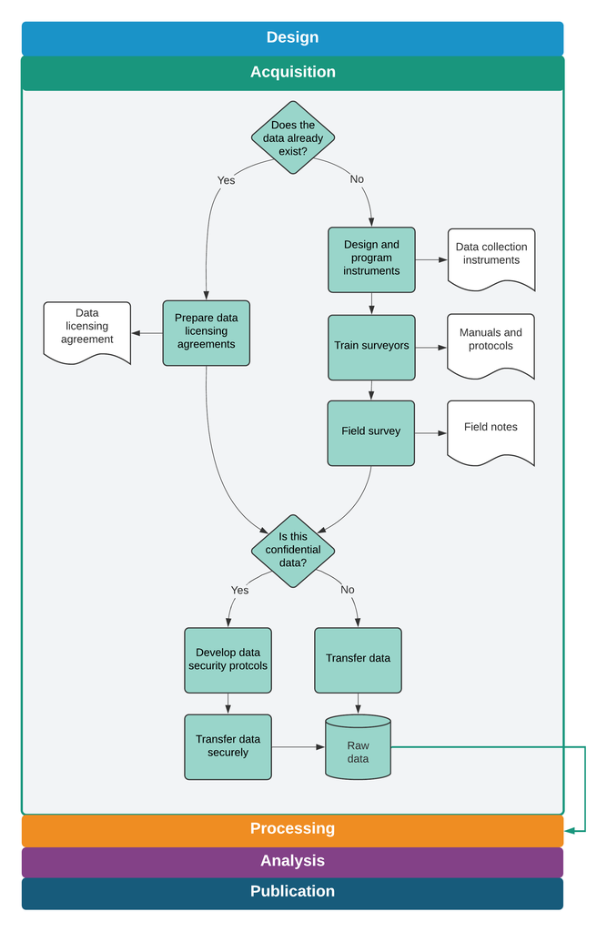

Data acquisition tasks and outputs

# 5 Cleaning and processing research data

Original data comes in a variety of formats, most of which are not immediately suited for analysis. The process of preparing data for analysis has many different names: data cleaning, data munging, data wrangling. But they all mean the same thing – transforming raw data into a convenient format for your intended use. This is the most time-consuming step of a project’s data work, particularly when primary data is involved; it is also essential for data quality. A structured workflow for preparing newly-acquired data for analysis is essential for efficient, transparent, and reproducible data work. One key point of this chapter is that no changes are made to the contents of data at this point. We consider creating new variables, imputing values and correcting outliers to be research decisions, and will discuss those in the next chapter. Therefore, the clean dataset, which is the main output from the workflow discussed in this chapter, contains the same information as the raw data, but in a format that is ready for use with statistical software.

This chapter describes the various tasks involved in making newly-acquired data ready for analysis. The first section teaches you how to make your data *tidy*. This means adjusting how the dataset is organized until the relationship between rows and columns is well-defined. The second section describes quality assurance checks, which are necessary to verify data accuracy. The third section covers de-identification, as removing direct identifiers early in the data handling process helps to ensure privacy. The final section discusses how to examine each variable in your dataset and make sure that it is as well documented and as easy to use as possible. Each of these tasks is implemented through code, and resulting datasets can be reproduced exactly by running this code. The raw data files are kept exactly as they were acquired, and no changes are made directly to them.

## Making data “tidy”

The very first step in creating an analysis-friendly dataset is understanding the data acquired, and using this understanding to translate the data into an intuitive format. This section discusses what steps may be needed to make sure that each row in your **data tables**[^189] represents one observation. Getting to such a format may be harder than expected, and the **unit of observation**[^190] may be ambiguous in many raw datasets. This section will present what we call a *tidy* data format, which is, in our experience, the ideal format to handle tabular data. We will treat tidying data as the first step in data cleaning even though, in practice, both tidying and quality monitoring should be done simultaneously as data is received. This is because quality assurance can only be finalized using tidied data, when it is guaranteed that each observation is uniquely identified.

### Establishing a unique identifier

An important step before starting to tidy a dataset is to understand the **unit of observation** and find out which variable or set of variables is the **unique identifier** for each observation.[^191] As discussed in Chapter 3, the unique identifier will be used to link observations in this dataset to data in other data sources according to the **data linkage table**,[^192] and the unique identifier for all observations must be listed in the **master dataset**.[^193] Ensuring that observations are uniquely and fully identified is arguably the most important step in data cleaning. It may be the case that the variables expected to uniquely identify the raw data contain either missing or duplicate values.[^194]

It is also possible for a raw dataset to not include an unique identifier, or that the identifier is not a suitable **project ID**.[^195] Suitable project IDs should, for example, not involve long strings that are difficult to work with, such as a name, or be an ID that is known outside the research team. In such cases, cleaning begins by adding a project ID to the raw data. If a project ID already exists, for this unit of observation, then you should carefully merge it from the master dataset to the raw data using other identifying information.[^196] If a project ID does not exist, then you need to generate one, add it to the master dataset, and then merge it back into the raw data. Note that while digital survey tools create unique identifiers for each data submission, that is not the same as having a unique ID variable for each observation in the sample, as there can be multiple submissions for the same observation.

DIME Analytics created an automated workflow to identify, correct and document occurrences of duplicated entries in the unique identifier using `ieduplicates` and `iecompdup`, two Stata commands included in the `iefieldkit` package. One advantage of using `ieduplicates`[^197] to correct duplicated entries is that it creates *duplicates reports* which records each corrections made and documents the reason for it. Even if you are not using this command, it is important to keep a record of all cases of duplicated IDs encountered and how they were resolved.